# Non-Ideal Reactors - Investigating Backmixing in Tubular reactors

## Chemical Reaction Engineering 3 - Assignment 4

Group 4

- Julian Stierstorfer (1160552)
- Akshay Archak (3069479)
- Girijasri Rajendran (3104516)

# 1. Introduction

Ideal reactor models are important simplifications in chemical reaction engineering. They reduce the real flow and mixing behaviour of reactors to limiting cases that can be described with compact balance equations. For tubular reactors, the plug-flow tubular reactor (PFTR) assumes ideal convective transport in axial direction, no radial concentration or temperature gradients and no axial backmixing. Under these assumptions, all fluid elements move through the reactor with the same residence time, and the reactor can be modelled as an initial value problem along the reactor length.

In real reactors, these ideal assumptions are only approximations. Deviations can arise from velocity profiles, molecular diffusion, turbulent dispersion, entrance effects or local recirculation zones. One important form of non-ideal behaviour is axial backmixing, where material is transported opposite to the main flow direction. This broadens the residence time distribution and changes the local concentration profile compared to the ideal PFTR. As a result, the conversion can differ from the ideal plug-flow prediction.

In this study, a tubular reactor with a length of $L = 10~\mathrm{m}$ and a diameter of $d_{\mathrm{R}} = 32~\mathrm{mm}$ is investigated. The reactor is fed from an upstream section with a diameter of $d_0 = 150~\mathrm{mm}$. The volumetric flow rate is $\dot{V} = 1~\mathrm{L,s^{-1}}$, and the feed contains component $\mathrm{A}$ with an inlet concentration of $c_{\mathrm{A},0} = 100~\mathrm{mol,m^{-3}}$.

The investigated reaction is assumed to be an irreversible reaction from component $\mathrm{A}$ to component $\mathrm{B}$.

\begin{equation} \mathrm{A} \rightarrow \mathrm{B} \tag{1} \end{equation}

This study investigates the influence of axial backmixing in tubular reactors for this simplified reaction system. The ideal PFTR is first used as the reference case without axial dispersion. Non-ideal behaviour is then introduced using the axial dispersion model, where the degree of backmixing is described by the Bodenstein number. High Bodenstein numbers correspond to weak dispersion and approach ideal plug-flow behaviour, while low Bodenstein numbers represent stronger backmixing and increasingly mixed-flow characteristics.

In addition, a CSTR cascade is implemented as an alternative representation of non-ideal tubular reactor behaviour. By increasing the number of ideally mixed tanks, the cascade approaches plug-flow behaviour, whereas a small number of tanks represents stronger mixing. The comparison between the ideal PFTR, the axial dispersion model and the CSTR cascade is used to evaluate how backmixing influences concentration profiles, outlet conversion and the transition between ideal and non-ideal reactor behaviour.

# 2. Theoretical Background: Ideal and Non-Ideal PFTRs

## 2.1 Ideal PFTR

The ideal PFTR is used as the limiting case without axial backmixing. The reactor is described by a one-dimensional steady-state material balance along the reactor coordinate $z$. The reaction is assumed to be irreversible and follows a power-law rate expression with respect to component $\mathrm{A}$. For first-order kinetics, the reaction order is set to $n=1$, but the following equations are written for a general reaction order $n$.

Main assumptions:

- steady-state operation
- one-dimensional flow in axial direction
- constant superficial velocity $u$
- constant density and reactor cross-section
- no radial concentration gradients
- no axial dispersion or backmixing
- isothermal operation with constant rate constant $k$
- irreversible reaction $\mathrm{A} \rightarrow \mathrm{B}$
- power-law kinetics with reaction order $n$

For the reaction rate,

\begin{equation} r = k c_{\mathrm{A}}^{n} \tag{2} \end{equation}

the steady-state component balances are:

\begin{equation} u \frac{\mathrm{d} c_{\mathrm{A}}}{\mathrm{d} z} = -r \qquad u \frac{\mathrm{d} c_{\mathrm{B}}}{\mathrm{d} z} = r \tag{3} \end{equation}

With Eq. (2), the balance for component $\mathrm{A}$ becomes:

\begin{equation} \frac{\mathrm{d} c_{\mathrm{A}}}{\mathrm{d} z} = -\frac{k}{u} c_{\mathrm{A}}^{n} \tag{4} \end{equation}

The initial conditions are defined at the reactor inlet:

\begin{equation} c_{\mathrm{A}}(0) = c_{\mathrm{A},0} \qquad c_{\mathrm{B}}(0) = c_{\mathrm{B},0} \tag{5} \end{equation}

The conversion of component $\mathrm{A}$ is calculated from the outlet concentration:

\begin{equation} X_{\mathrm{A}} = 1 - \frac{c_{\mathrm{A}}(L)}{c_{\mathrm{A},0}} \tag{6} \end{equation}

The ideal PFTR model is therefore an initial value problem. Since axial dispersion is neglected, the inlet concentration directly fixes the concentration profile along the reactor length.

## 2.2 Non-Ideal PFTR with Axial Dispersion

Real tubular reactors can deviate from ideal plug-flow behaviour because fluid elements do not necessarily move through the reactor with one identical residence time. Axial dispersion is used to describe this non-ideal behaviour by adding a dispersion term to the convective material balance. This term represents axial backmixing and is mathematically analogous to diffusive transport in the axial direction.

Main assumptions:

- steady-state operation
- one-dimensional axial reactor model
- constant reactor cross-section $A$
- constant superficial velocity $u$ inside the reactor
- constant axial dispersion coefficient $\mathcal{D}$
- no radial concentration gradients
- isothermal operation with constant rate constant $k$
- irreversible reaction $\mathrm{A} \rightarrow \mathrm{B}$
- power-law kinetics with reaction order $n$
- axial backmixing represented by the dispersion term

For a general component $i$, the steady-state material balance with axial dispersion is:

\begin{equation} u \frac{\mathrm{d} c_i}{\mathrm{d} z} = \mathcal{D} \frac{\mathrm{d}^2 c_i}{\mathrm{d} z^2} + \sum_{j=1}^{M} \nu_{i,j} r_j \tag{7} \end{equation}

For the investigated reaction, Eq. (7) gives the component balances for $\mathrm{A}$ and $\mathrm{B}$:

\begin{equation} \mathcal{D} \frac{\mathrm{d}^{2} c_{\mathrm{A}}}{\mathrm{d} z^{2}} - u \frac{\mathrm{d} c_{\mathrm{A}}}{\mathrm{d} z} - r = 0 \qquad \mathcal{D} \frac{\mathrm{d}^{2} c_{\mathrm{B}}}{\mathrm{d} z^{2}} - u \frac{\mathrm{d} c_{\mathrm{B}}}{\mathrm{d} z} + r = 0 \tag{8} \end{equation}

With the power-law rate expression from Eq. (2), the balance for component $\mathrm{A}$ becomes:

\begin{equation} \mathcal{D} \frac{\mathrm{d}^{2} c_{\mathrm{A}}}{\mathrm{d} z^{2}} - u \frac{\mathrm{d} c_{\mathrm{A}}}{\mathrm{d} z} - k c_{\mathrm{A}}^{n} = 0 \tag{9} \end{equation}

In contrast to the ideal PFTR, the axial dispersion model contains second-order spatial derivatives. Therefore, the reactor cannot be solved as an initial value problem with inlet concentrations only. Boundary conditions are required at both reactor ends. This is physically necessary because the concentration at the reactor inlet is influenced by backmixing from downstream positions. Therefore, the concentration directly at $z=0$ is not necessarily equal to the upstream feed concentration.

At the inlet, the Danckwerts boundary condition is formulated as a molar flux balance across the reactor boundary. The molar flow entering from the upstream section must be equal to the sum of convective and dispersive molar transport at the reactor inlet:

\begin{equation} z = 0: \qquad u_0 A_0 c_{i,0} = u A c_i(0) - A \mathcal{D} \left.\frac{\mathrm{d} c_i}{\mathrm{d} z}\right|_{z=0} \qquad i = \mathrm{A}, \mathrm{B} \tag{10} \end{equation}

Here, $u_0$, $A_0$ and $c_{i,0}$ describe the velocity, cross-sectional area and concentration in the upstream feed section. The corresponding reactor quantities are $u$, $A$ and $c_i(0)$ at the reactor inlet. The term $u A c_i(0)$ describes convective transport into the reactor, while $-A \mathcal{D} \mathrm{d}c_i/\mathrm{d}z$ describes axial dispersive transport. This formulation allows $c_i(0)$ to differ from the upstream feed concentration $c_{i,0}$.

For constant volumetric flow rate,

\begin{equation} \dot{V} = u_0 A_0 = u A \tag{11} \end{equation}

Eq. (10) can be written as:

\begin{equation} z = 0: \qquad \dot{V} c_{i,0} = \dot{V} c_i(0) - A \mathcal{D} \left.\frac{\mathrm{d} c_i}{\mathrm{d} z}\right|_{z=0} \qquad i = \mathrm{A}, \mathrm{B} \tag{12} \end{equation}

If the upstream section and the reactor have the same cross-sectional area and velocity, Eq. (10) further simplifies to:

\begin{equation} z = 0: \qquad u \left(c_{i,0} - c_i(0)\right) = -\mathcal{D} \left.\frac{\mathrm{d} c_i}{\mathrm{d} z}\right|_{z=0} \qquad i = \mathrm{A}, \mathrm{B} \tag{13} \end{equation}

This simplified inlet condition shows the role of backmixing directly. The difference between the upstream feed concentration and the concentration at the reactor inlet is balanced by the dispersive flux. If axial dispersion becomes negligible, the gradient term vanishes and the ideal PFTR inlet condition $c_i(0) = c_{i,0}$ is recovered.

At the outlet, the Danckwerts boundary condition is given by a zero-gradient condition:

\begin{equation} z = L: \qquad \left.\frac{\mathrm{d} c_i}{\mathrm{d} z}\right|_{z=L} = 0 \qquad i = \mathrm{A}, \mathrm{B} \tag{14} \end{equation}

This condition assumes that no additional axial concentration change is imposed downstream of the reactor. The concentration profile is therefore forced to become flat at the reactor outlet. Together, Eqs. (10) and (14) close the boundary value problem for each component.

The strength of axial backmixing is described by the Bodenstein number:

\begin{equation} Bo = \frac{u L}{\mathcal{D}} \tag{15} \end{equation}

The Bodenstein number compares convective transport with axial dispersion. High values of $Bo$ correspond to weak axial dispersion and approach ideal PFTR behaviour. Low values of $Bo$ correspond to stronger axial backmixing and broader residence time distributions. Therefore, the axial dispersion model is used to investigate the transition from ideal plug-flow behaviour to increasingly non-ideal reactor behaviour.

Mathematically, this distinction means that the ideal PFTR is formulated as an initial value problem, while the non-ideal PFTR with axial dispersion is formulated as a boundary value problem.

## 2.3 Residence Time Distribution of Ideal and Non-Ideal PFTRs

The residence time distribution describes how long fluid elements remain inside the reactor. For an ideal PFTR, plug-flow behaviour is assumed. This means that all fluid elements move through the reactor with the same residence time. Therefore, the cumulative distribution function is a step function at the mean residence time.

\begin{equation} F(t) = H(t-\tau) = \left\{ \begin{array}{ll} 1, & t > \tau \\ 0, & t < \tau \end{array} \right. \tag{16} \end{equation}

Here, $\tau$ is the residence time and $H(t-\tau)$ is the Heaviside step function shifted by the residence time. Eq. (16) expresses that all fluid elements leave the ideal PFTR at the same time. Therefore, the RTD of an ideal PFTR is infinitely narrow.

Real tubular reactors can deviate from this ideal behaviour. One reason is the influence of viscous forces on the velocity profile. In laminar pipe flow, the velocity is not constant over the reactor radius, but follows a parabolic profile:

\begin{equation} u(r) = 2 \bar{u} \left[ 1 - \left(\frac{r}{R}\right)^2 \right] \tag{17} \end{equation}

Here, $u(r)$ is the local velocity, $\bar{u}$ is the mean velocity, $r$ is the radial position and $R$ is the reactor radius. Since the fluid close to the wall moves more slowly than the fluid in the centre, fluid elements have different residence times. For laminar flow, the cumulative distribution function can be written as:

\begin{equation} F(t) = 1 - \frac{1}{4} \left(\frac{\bar{t}}{t}\right)^2 \tag{18} \end{equation}

with the mean residence time:

\begin{equation} \bar{t} = \frac{L}{\bar{u}} = \bar{\tau} \tag{19} \end{equation}

Compared to the ideal PFTR, Eq. (18) does not describe an instant step. Instead, the residence times are distributed because different fluid elements move with different velocities. Consequently, some fluid elements leave the reactor earlier than the mean residence time, while others remain inside the reactor for a longer time and leave later.

For the axial dispersion model, the cumulative distribution function changes from the ideal step function to a continuous function. This represents the effect of backmixing in the reactor. The corresponding differential representation of the cumulative distribution function is the residence time distribution $E(\Theta)$, with the dimensionless time $\Theta = t / \bar{t}$.

\begin{equation} \int_{-\infty}^{+\infty} E(\Theta) \ \mathrm{d}\Theta = 1 \tag{20} \end{equation}

The RTD for the dispersion model can be expressed using the Bodenstein number:

\begin{equation} E(\Theta) = \frac{1}{\sqrt{4 \pi / Bo}} \exp \left[-\frac{(1-\Theta)^2}{4 / Bo}\right] \tag{21} \end{equation}

The Bodenstein number therefore links the RTD to the strength of axial dispersion. A high $Bo$ value corresponds to weak dispersion and gives a sharper RTD, which approaches ideal plug-flow behaviour. A lower $Bo$ value corresponds to stronger dispersion and therefore a broader RTD. Thus, the ideal PFTR is represented by an instantaneous residence time, while the non-ideal PFTR is represented by a distributed residence time caused by non-ideal flow and backmixing.

## 2.4 Reaction System

The investigated reactor and reaction system are summarized in Table 1.

**Table 1:** Reactor and reaction system used for the numerical investigation.

| Quantity | Symbol | Value |
| --- | --- | --- |
| Reactor length | $L$ | $10~\mathrm{m}$ |
| Reactor diameter | $d_{\mathrm{R}}$ | $32~\mathrm{mm}$ |
| Upstream inlet diameter | $d_0$ | $150~\mathrm{mm}$ |
| Volumetric flow rate | $\dot{V}$ | $1~\mathrm{L,s^{-1}}$ |
| Feed concentration of $\mathrm{A}$ | $c_{\mathrm{A},0}$ | $100~\mathrm{mol,m^{-3}}$ |
| Feed concentration of $\mathrm{B}$ | $c_{\mathrm{B},0}$ | $0~\mathrm{mol,m^{-3}}$ |
| Reaction rate constant | $k$ | varied |
| Dispersion coefficient | $\mathcal{D}$ | varied |
| Bodenstein number | $Bo$ | varied |
| Reaction type | - | first-order, irreversible |

## 2.5 Importing packages and parameters

First, all needed packages for calculation, numerical solution and data visualisation is imported:

```python
# importing packages
import numpy as np
import matplotlib.pyplot as plt
from scipy.integrate import solve_ivp, solve_bvp
from scipy.optimize import root
import ICIW_Plots
import ICIW_Plots.colors as ICIWcolors
```

Additionally, a custom plot structure is defined

```python
# Project setup: packages and ICIW plotting style

from pathlib import Path
from cycler import cycler

import numpy as np
import matplotlib.pyplot as plt

from scipy.integrate import solve_ivp, solve_bvp
from scipy.optimize import root

import pandas as pd
from IPython.display import Markdown, display

import ICIW_Plots
import ICIW_Plots.colors as ICIWcolors


# Locate and apply ICIW style
iciw_package_dir = Path(ICIW_Plots.__file__).resolve().parent
iciw_style_files = list(iciw_package_dir.rglob("*.mplstyle"))

iciw_style_path = None
for file in iciw_style_files:
    if file.stem == "ICIWstyle":
        iciw_style_path = file
        break

if iciw_style_path is None:
    raise FileNotFoundError("ICIWstyle.mplstyle was not found in the ICIW_Plots package.")

plt.style.use(str(iciw_style_path))


# ICIW project color cycle
iciw_color_cycle = [
    ICIWcolors.CERULEAN,
    ICIWcolors.CRIMSON,
    ICIWcolors.DRAB,
    ICIWcolors.FLAME,
    ICIWcolors.KELLYGREEN,
    ICIWcolors.WELDONBLUE,
]

plt.rcParams["axes.prop_cycle"] = cycler(color=iciw_color_cycle)


# Shared plotting options
linestyles = ["-", "--", "-.", ":", (0, (5, 2)), (0, (3, 1, 1, 1))]
markers = ["o", "s", "^", "D", "v", "P"]


def get_plot_style(i):
    """
    Return repeated ICIW color, linestyle and marker for parameter studies.
    """
    return {
        "color": iciw_color_cycle[i % len(iciw_color_cycle)],
        "linestyle": linestyles[i % len(linestyles)],
        "marker": markers[i % len(markers)],
    }


print(f"Using ICIW style: {iciw_style_path.name}")
print("ICIW color cycle: CERULEAN, CRIMSON, DRAB, FLAME, KELLYGREEN, WELDONBLUE")# Project setup: packages and ICIW plotting style

from pathlib import Path
from cycler import cycler

import numpy as np
import matplotlib.pyplot as plt

from scipy.integrate import solve_ivp, solve_bvp
from scipy.optimize import root

import ICIW_Plots
import ICIW_Plots.colors as ICIWcolors


# Locate and apply ICIW style
iciw_package_dir = Path(ICIW_Plots.__file__).resolve().parent
iciw_style_files = list(iciw_package_dir.rglob("*.mplstyle"))

iciw_style_path = None
for file in iciw_style_files:
    if file.stem == "ICIWstyle":
        iciw_style_path = file
        break

if iciw_style_path is None:
    raise FileNotFoundError("ICIWstyle.mplstyle was not found in the ICIW_Plots package.")

plt.style.use(str(iciw_style_path))


# ICIW project color cycle
iciw_color_cycle = [
    ICIWcolors.CERULEAN,
    ICIWcolors.CRIMSON,
    ICIWcolors.DRAB,
    ICIWcolors.FLAME,
    ICIWcolors.KELLYGREEN,
    ICIWcolors.WELDONBLUE,
]

plt.rcParams["axes.prop_cycle"] = cycler(color=iciw_color_cycle)


# Shared plotting options
linestyles = ["-", "--", "-.", ":", (0, (5, 2)), (0, (3, 1, 1, 1))]
markers = ["o", "s", "^", "D", "v", "P"]


def get_plot_style(i):
    """
    Return repeated ICIW color, linestyle and marker for parameter studies.
    """
    return {
        "color": iciw_color_cycle[i % len(iciw_color_cycle)],
        "linestyle": linestyles[i % len(linestyles)],
        "marker": markers[i % len(markers)],
    }


print(f"Using ICIW style: {iciw_style_path.name}")
print("ICIW color cycle: CERULEAN, CRIMSON, DRAB, FLAME, KELLYGREEN, WELDONBLUE")
```

```
Using ICIW style: ICIWstyle.mplstyle
ICIW color cycle: CERULEAN, CRIMSON, DRAB, FLAME, KELLYGREEN, WELDONBLUE
Using ICIW style: ICIWstyle.mplstyle
ICIW color cycle: CERULEAN, CRIMSON, DRAB, FLAME, KELLYGREEN, WELDONBLUE
```

Then, important import parameters are defined. In this case a reaction order of 1, as well as a reaction rate constant of $1\; \mathrm{s^{-1}}$ is assumed. A Bodenstein number of $Bo = 20$ is used as the first non-ideal reference case. This value represents moderate axial dispersion, because convective transport is still dominant while axial backmixing is already large enough to cause visible deviations from ideal plug-flow behaviour.

Thus, high $Bo$ values approach the ideal PFTR limit, while lower $Bo$ values represent stronger axial dispersion. Therefore, $Bo = 20$ is suitable for the first comparison between the ideal PFTR and the non-ideal dispersion model.

```python
# input parameters
L = 10.0                         # reactor length, m
D = 32e-3                        # reactor diameter, m
D_upstream = 150e-3              # upstream inlet diameter, m
V_dot = 0.001                    # volumetric flow rate, m^3 s^-1
c_A_in = 100.0                   # inlet concentration A, mol m^-3
c_in = np.array([c_A_in, 0.0])    # inlet concentration vector [A, B], mol m^-3
stoich_coeff = np.array([-1, 1]) # stoichiometric coefficients for A -> B, -
k = 1.0                          # rate constant, unit depends on n
n = 1.0                          # reaction order, -
Bo = 20.0                        # Bodenstein number, -
```

The reactor and flow parameters are calculated from the previously defined input values. First, the reactor and upstream cross-sectional areas are determined from the corresponding diameters. The reactor volume is then calculated from the reactor area and length.

Using the volumetric flow rate, the superficial velocities in the reactor and in the upstream section are calculated. These velocities are required because the Danckwerts inlet boundary condition distinguishes between upstream and reactor quantities. The space time $\tau$ describes the nominal residence time in the reactor, while the axial dispersion coefficient is calculated from the selected Bodenstein number.

\begin{equation} \mathcal{D} = \frac{uL}{Bo} \tag{22} \end{equation}

The arrays `z_eval` and `z_mesh` define the axial positions used for evaluating and solving the numerical models. The tolerances `rtol_ivp`, `atol_ivp`, `tol_bvp` and `max_nodes_bvp` specify the numerical accuracy settings for the IVP and BVP solvers. These values can be adapted in case of convergence problems of the numerical solver.

```python
# reactor and flow parameters
A = np.pi * D**2 / 4             # reactor cross-sectional area, m^2
A_0 = np.pi * D_upstream**2 / 4  # upstream cross-sectional area, m^2
V = A * L                        # reactor volume, m^3

u = V_dot / A                    # superficial velocity in reactor, m s^-1
u_0 = V_dot / A_0                # upstream superficial velocity, m s^-1

tau = L / u                      # space time, s
D_ax = u * L / Bo                # axial dispersion coefficient, m^2 s^-1

z_eval = np.linspace(0.0, L, 300)
z_mesh = np.linspace(0.0, L, 250)

rtol_ivp = 1e-8
atol_ivp = 1e-10

tol_bvp = 1e-5
max_nodes_bvp = 10000

print(f"A = {A:.4e} m^2")
print(f"V = {V:.4e} m^3")
print(f"u = {u:.4f} m s^-1")
print(f"u_0 = {u_0:.4f} m s^-1")
print(f"tau = {tau:.4f} s")
print(f"D_ax = {D_ax:.4e} m^2 s^-1")
```

```
A = 8.0425e-04 m^2
V = 8.0425e-03 m^3
u = 1.2434 m s^-1
u_0 = 0.0566 m s^-1
tau = 8.0425 s
D_ax = 6.2170e-01 m^2 s^-1
```

## 3.1 Ideal PFTR Implementation

To investigate the ideal reactor behaviour, the PFTR model is implemented in the function `pftr_model`. This function contains the component balances for the irreversible reaction $\mathrm{A} \rightarrow \mathrm{B}$ with power-law kinetics. The reaction order $n$ can be varied in the implementation. For the investigated first-order case, $n = 1$ is used.

The state vector is defined as:

\begin{equation} \mathbf{y} = \begin{bmatrix} c_{\mathrm{A}} \\ c_{\mathrm{B}} \end{bmatrix} \tag{23} \end{equation}

Using the rate expression $r = k c_{\mathrm{A}}^{n}$, the implemented balance equations are:

\begin{equation} \frac{\mathrm{d} c_{\mathrm{A}}}{\mathrm{d} z} = -\frac{k}{u} c_{\mathrm{A}}^{n} \qquad \frac{\mathrm{d} c_{\mathrm{B}}}{\mathrm{d} z} = \frac{k}{u} c_{\mathrm{A}}^{n} \tag{24} \end{equation}

The initial conditions are given by the feed concentrations at the reactor inlet:

\begin{equation} c_{\mathrm{A}}(0) = c_{\mathrm{A},0} \qquad c_{\mathrm{B}}(0) = c_{\mathrm{B},0} \tag{25} \end{equation}

Since only inlet values are required, the ideal PFTR is solved as an initial value problem. The outlet conversion is calculated from the final value of $c_{\mathrm{A}}$:

\begin{equation} X_{\mathrm{A}} = 1 - \frac{c_{\mathrm{A}}(L)}{c_{\mathrm{A},0}} \tag{26} \end{equation}

```python
def reaction_rate(c_A, k, n):
    """
    Calculate the reaction rate for the power-law reaction A -> B.

    Inputs
    ------
    c_A : float or np.ndarray
        Concentration of reactant A, mol m^-3.
    k : float
        Reaction rate constant. Unit depends on reaction order n:
        (mol m^-3)^(1-n) s^-1.
    n : float
        Reaction order with respect to A, -.

    Output
    ------
    r : float or np.ndarray
        Reaction rate, mol m^-3 s^-1.
    """
    c_A_physical = np.maximum(c_A, 0.0)   # avoids non-physical negative rates
    r = k * c_A_physical**n              # reaction rate, mol m^-3 s^-1

    return r


def pftr_model(z, c, k, n, stoich_coeff, u):
    """
    Define the ideal PFTR model for the reaction A -> B.

    Inputs
    ------
    z : float
        Axial reactor coordinate, m.
    c : np.ndarray
        Concentration vector [c_A, c_B], mol m^-3.
    k : float
        Reaction rate constant. Unit depends on reaction order n:
        (mol m^-3)^(1-n) s^-1.
    n : float
        Reaction order with respect to A, -.
    stoich_coeff : np.ndarray
        Stoichiometric coefficient vector [nu_A, nu_B], -.
    u : float
        Superficial velocity in the reactor, m s^-1.

    Output
    ------
    dc_dz : np.ndarray
        Axial concentration gradients [dc_A/dz, dc_B/dz], mol m^-4.
    """
    c_A = c[0]                            # concentration of A, mol m^-3

    r = reaction_rate(c_A, k, n)          # reaction rate, mol m^-3 s^-1
    dc_dz = stoich_coeff * r / u         # concentration gradient, mol m^-4

    return dc_dz


sol_pftr = solve_ivp(
    fun=pftr_model,
    t_span=(0.0, L),
    y0=c_in,
    args=(k, n, stoich_coeff, u),
    t_eval=z_eval,
    method="RK45",
    rtol=rtol_ivp,
    atol=atol_ivp,
)

if not sol_pftr.success:
    raise RuntimeError(sol_pftr.message)

z_pftr = sol_pftr.t                       # axial coordinates, m
c_pftr = sol_pftr.y                       # concentration profiles, mol m^-3

c_A_pftr = c_pftr[0]                      # concentration profile of A, mol m^-3
c_B_pftr = c_pftr[1]                      # concentration profile of B, mol m^-3

X_A_pftr = 1.0 - c_A_pftr[-1] / c_A_in    # outlet conversion of A, -

print(f"PFTR outlet conversion: X_A = {X_A_pftr:.5f}")
print(f"PFTR outlet c_A = {c_A_pftr[-1]:.5f} mol m^-3")
print(f"PFTR outlet c_B = {c_B_pftr[-1]:.5f} mol m^-3")
```

```
PFTR outlet conversion: X_A = 0.99968
PFTR outlet c_A = 0.03215 mol m^-3
PFTR outlet c_B = 99.96785 mol m^-3
```

## 3.2 Non-Ideal Tubular Reactor Implementation with Axial Dispersion

The non-ideal tubular reactor is implemented using the axial dispersion model. The model is split into two functions. The function `dispersion_model` contains the differential equations, while the function `dispersion_boundary_conditions` contains the Danckwerts boundary conditions at the inlet and outlet.

The second-order dispersion balances are rewritten as a system of first-order differential equations. For the irreversible reaction $\mathrm{A} \rightarrow \mathrm{B}$ with power-law kinetics, the second-order balances are:

\begin{equation} \mathcal{D} \frac{\mathrm{d}^{2} c_{\mathrm{A}}}{\mathrm{d} z^{2}} - u \frac{\mathrm{d} c_{\mathrm{A}}}{\mathrm{d} z} - k c_{\mathrm{A}}^{n} = 0 \qquad \mathcal{D} \frac{\mathrm{d}^{2} c_{\mathrm{B}}}{\mathrm{d} z^{2}} - u \frac{\mathrm{d} c_{\mathrm{B}}}{\mathrm{d} z} + k c_{\mathrm{A}}^{n} = 0 \tag{27} \end{equation}

The state vector for the boundary value problem is defined as:

\begin{equation} \mathbf{y} = \begin{bmatrix} y_1 \\ y_2 \\ y_3 \\ y_4 \end{bmatrix} = \begin{bmatrix} c_{\mathrm{A}} \\ \frac{\mathrm{d} c_{\mathrm{A}}}{\mathrm{d} z} \\ c_{\mathrm{B}} \\ \frac{\mathrm{d} c_{\mathrm{B}}}{\mathrm{d} z} \end{bmatrix} \tag{28} \end{equation}

This gives the following first-order system implemented in `dispersion_model`:

\begin{equation} \frac{\mathrm{d} y_1}{\mathrm{d} z} = y_2 \qquad \frac{\mathrm{d} y_2}{\mathrm{d} z} = \frac{u y_2 + k y_1^{n}}{\mathcal{D}} \tag{29} \end{equation}

\begin{equation} \frac{\mathrm{d} y_3}{\mathrm{d} z} = y_4 \qquad \frac{\mathrm{d} y_4}{\mathrm{d} z} = \frac{u y_4 - k y_1^{n}}{\mathcal{D}} \tag{30} \end{equation}

The function `dispersion_boundary_conditions` applies the Danckwerts inlet condition and the zero-gradient outlet condition. At the inlet, the upstream molar flow is balanced with the convective and dispersive transport at the reactor boundary:

\begin{equation} u_0 A_0 c_{i,0} = u A c_i(0) - A \mathcal{D} \left. \frac{\mathrm{d} c_i}{\mathrm{d} z} \right|_{z=0} \qquad i = \mathrm{A}, \mathrm{B} \tag{31} \end{equation}

At the outlet, the axial concentration gradient is set to zero:

\begin{equation} \left. \frac{\mathrm{d} c_i}{\mathrm{d} z} \right|_{z=L} = 0 \qquad i = \mathrm{A}, \mathrm{B} \tag{32} \end{equation}

Since the dispersion model is solved with `solve_bvp`, an initial guess for the complete state vector has to be provided on the numerical mesh. This initial guess is not a physical boundary condition, but only a starting profile for the iterative BVP solver. To keep the implementation simple and physically reasonable, constant concentration profiles are used as initial guesses. The reactant concentration is initialized with the feed concentration, the product concentration with the product feed concentration, and both concentration gradients are initialized with zero:

\begin{equation} \mathbf{y}_{\mathrm{guess}}(z) = \begin{bmatrix} c_{\mathrm{A},0} \\ 0 \\ c_{\mathrm{B},0} \\ 0 \end{bmatrix} \tag{33} \end{equation}

This choice is more physical than a complete zero initialization, because the feed contains component $\mathrm{A}$. At the same time, it keeps the implementation independent of the ideal PFTR solution and avoids using the PFTR result as a numerical pre-solution for the dispersion model.

The dispersion model is therefore solved as a boundary value problem. In contrast to the ideal PFTR, the concentration at the reactor inlet is part of the solution and does not have to be identical to the upstream feed concentration. For the investigated first-order case, the reaction order is set to $n = 1$ in the implementation.

```python
def dispersion_model(z, y, k, n, stoich_coeff, u, D_ax):
    """
    Define the axial dispersion model as a first-order differential equation system.

    State vector
    ------------
    y[0] = c_A
        Concentration of reactant A, mol m^-3.
    y[1] = dc_A/dz
        Axial concentration gradient of A, mol m^-4.
    y[2] = c_B
        Concentration of product B, mol m^-3.
    y[3] = dc_B/dz
        Axial concentration gradient of B, mol m^-4.

    Inputs
    ------
    z : float or np.ndarray
        Axial reactor coordinate, m.
    y : np.ndarray
        State matrix with shape (4, len(z)) for solve_bvp.
    k : float
        Reaction rate constant. Unit depends on n:
        (mol m^-3)^(1-n) s^-1.
    n : float
        Reaction order with respect to A, -.
    stoich_coeff : np.ndarray
        Stoichiometric coefficient vector [nu_A, nu_B], -.
    u : float
        Superficial velocity in the reactor, m s^-1.
    D_ax : float
        Axial dispersion coefficient, m^2 s^-1.

    Output
    ------
    dy_dz : np.ndarray
        Derivatives of the state vector with shape (4, len(z)).
    """
    c_A = y[0]                            # concentration of A, mol m^-3
    dc_A_dz = y[1]                        # concentration gradient of A, mol m^-4
    dc_B_dz = y[3]                        # concentration gradient of B, mol m^-4

    r = reaction_rate(c_A, k, n)          # reaction rate, mol m^-3 s^-1

    d2c_A_dz2 = (u * dc_A_dz - stoich_coeff[0] * r) / D_ax
    d2c_B_dz2 = (u * dc_B_dz - stoich_coeff[1] * r) / D_ax

    dy_dz = np.vstack((dc_A_dz, d2c_A_dz2, dc_B_dz, d2c_B_dz2))

    return dy_dz


def dispersion_boundary_conditions(ya, yb, c_in, u_0, A_0, u, A, D_ax):
    """
    Define Danckwerts boundary conditions for the axial dispersion model.

    Inputs
    ------
    ya : np.ndarray
        State vector at reactor inlet z = 0.
    yb : np.ndarray
        State vector at reactor outlet z = L.
    c_in : np.ndarray
        Inlet concentration vector [c_A,in, c_B,in], mol m^-3.
    u_0 : float
        Upstream superficial velocity, m s^-1.
    A_0 : float
        Upstream cross-sectional area, m^2.
    u : float
        Superficial velocity in the reactor, m s^-1.
    A : float
        Reactor cross-sectional area, m^2.
    D_ax : float
        Axial dispersion coefficient, m^2 s^-1.

    Output
    ------
    bc : np.ndarray
        Residuals of the four boundary conditions.
    """
    bc_A_in = u_0 * A_0 * c_in[0] - (u * A * ya[0] - A * D_ax * ya[1])
    bc_B_in = u_0 * A_0 * c_in[1] - (u * A * ya[2] - A * D_ax * ya[3])

    bc_A_out = yb[1]                      # dc_A/dz = 0 at z = L
    bc_B_out = yb[3]                      # dc_B/dz = 0 at z = L

    bc = np.array([bc_A_in, bc_B_in, bc_A_out, bc_B_out])

    return bc


# Physical initial guess for the BVP solver
y_guess = np.zeros((4, z_mesh.size))
y_guess[0, :] = c_in[0]                  # initial guess for c_A, mol m^-3
y_guess[1, :] = 0.0                      # initial guess for dc_A/dz, mol m^-4
y_guess[2, :] = c_in[1]                  # initial guess for c_B, mol m^-3
y_guess[3, :] = 0.0                      # initial guess for dc_B/dz, mol m^-4

# Boundary value problem
sol_disp = solve_bvp(
    fun=lambda z, y: dispersion_model(z, y, k, n, stoich_coeff, u, D_ax),
    bc=lambda ya, yb: dispersion_boundary_conditions(ya, yb, c_in, u_0, A_0, u, A, D_ax),
    x=z_mesh,
    y=y_guess,
    tol=tol_bvp,
    max_nodes=max_nodes_bvp,
)

if not sol_disp.success:
    raise RuntimeError(sol_disp.message)

# Results on common evaluation grid
z_disp = z_eval                          # axial coordinate, m
y_disp = sol_disp.sol(z_disp)            # evaluated BVP solution

c_A_disp = y_disp[0]                     # concentration profile of A, mol m^-3
dc_A_dz_disp = y_disp[1]                 # concentration gradient of A, mol m^-4
c_B_disp = y_disp[2]                     # concentration profile of B, mol m^-3
dc_B_dz_disp = y_disp[3]                 # concentration gradient of B, mol m^-4

X_A_disp = 1.0 - c_A_disp[-1] / c_in[0]  # outlet conversion of A, -

print(f"Dispersion model outlet conversion: X_A = {X_A_disp:.5f}")
print(f"Dispersion model inlet c_A = {c_A_disp[0]:.5f} mol m^-3")
print(f"Dispersion model outlet c_A = {c_A_disp[-1]:.5f} mol m^-3")
print(f"Dispersion model outlet c_B = {c_B_disp[-1]:.5f} mol m^-3")
print(f"BVP iterations = {sol_disp.niter}")
print(f"BVP mesh nodes = {sol_disp.x.size}")
```

```
Dispersion model outlet conversion: X_A = 0.99799
Dispersion model inlet c_A = 76.47939 mol m^-3
Dispersion model outlet c_A = 0.20138 mol m^-3
Dispersion model outlet c_B = 99.79862 mol m^-3
BVP iterations = 1
BVP mesh nodes = 250
```

## 3.3 CSTR Cascade Implementation

A CSTR cascade is implemented as an additional model for non-ideal reactor behaviour. The cascade consists of $N$ ideally mixed tanks in series. For $N = 1$, the system corresponds to one ideal CSTR with strong backmixing. With increasing $N$, the degree of backmixing decreases and the cascade approaches ideal PFTR behaviour.

The total space time is divided equally between all tanks:

\begin{equation} \tau_N = \frac{\tau}{N} \tag{34} \end{equation}

For each tank $m$, the steady-state component balance is:

\begin{equation} 0 = c_{i,m-1} - c_{i,m} + \tau_N \nu_i k c_{\mathrm{A},m}^{n} \qquad i = \mathrm{A}, \mathrm{B} \tag{35} \end{equation}

The outlet concentration of one tank is used as the inlet concentration of the next tank. After the last tank, the outlet conversion is calculated as:

\begin{equation} X_{\mathrm{A},N} = 1 - \frac{c_{\mathrm{A},N}}{c_{\mathrm{A},0}} \tag{36} \end{equation}

The number of tanks $N$ is therefore used as the parameter controlling the transition from mixed-flow behaviour to ideal plug-flow behaviour.

For the $\mathrm{CSTR}$-cascade, the number of included vessels as well as the residence time for the $\mathrm{PFTR}$ and the space-time of one vessel inside the cascade is defined:

```python
# CSTR cascade parameters

N_CSTR = 10                       # number of ideal CSTRs in cascade, -

tau_PFTR = V / V_dot              # PFTR space time, s
tau_CSTR = tau_PFTR / N_CSTR      # space time of one CSTR vessel, s

V_CSTR = V / N_CSTR               # volume of one CSTR vessel, m^3

print(f"N_CSTR = {N_CSTR:d}")
print(f"tau_PFTR = {tau_PFTR:.4f} s")
print(f"tau_CSTR = {tau_CSTR:.4f} s")
print(f"V_CSTR = {V_CSTR:.4e} m^3")
```

```
N_CSTR = 10
tau_PFTR = 8.0425 s
tau_CSTR = 0.8042 s
V_CSTR = 8.0425e-04 m^3
```

For reaction orders different from $n = 1$, the CSTR balance becomes nonlinear in the outlet concentration of each tank. Therefore, the algebraic balance equations are solved numerically with a root solver. For each tank $m$, the unknown outlet concentration vector is:

\begin{equation} \mathbf{c}_m = \begin{bmatrix} c_{\mathrm{A},m} \\ c_{\mathrm{B},m} \end{bmatrix} \tag{37} \end{equation}

The root solver determines $\mathbf{c}_m$ such that the residual of the CSTR balance becomes zero:

\begin{equation} \mathbf{R}(\mathbf{c}_m) = \mathbf{c}_{m-1} - \mathbf{c}_m + \tau_N \boldsymbol{\nu} k c_{\mathrm{A},m}^{n} = \mathbf{0} \tag{38} \end{equation}

After one tank is solved, its outlet concentration is used as the inlet concentration for the next tank. This tank-by-tank solution keeps the cascade implementation valid for different reaction orders. For $n = 1$, an analytical solution would be possible, but the root solver provides a more general implementation.

```python
def cstr_balance_residual(c_out, c_in_tank, tau_CSTR, k, n, stoich_coeff):
    """
    Calculate the residuals of the steady-state component balances
    for one CSTR in the cascade.

    The solver varies c_out until residual = [0, 0].

    Inputs
    ------
    c_out : np.ndarray
        Guessed outlet concentration vector of the current CSTR
        [c_A,out, c_B,out], mol m^-3.
    c_in_tank : np.ndarray
        Inlet concentration vector of the current CSTR
        [c_A,in, c_B,in], mol m^-3.
    tau_CSTR : float
        Space time of one CSTR vessel, s.
    k : float
        Reaction rate constant. Unit depends on reaction order n:
        (mol m^-3)^(1-n) s^-1.
    n : float
        Reaction order with respect to A, -.
    stoich_coeff : np.ndarray
        Stoichiometric coefficient vector [nu_A, nu_B], -.

    Output
    ------
    residual : np.ndarray
        Balance residual vector [res_A, res_B], mol m^-3.
    """
    c_A_out = c_out[0]                                  # outlet concentration of A, mol m^-3

    r = reaction_rate(c_A_out, k, n)                    # reaction rate, mol m^-3 s^-1
    residual = c_in_tank - c_out + tau_CSTR * stoich_coeff * r

    return residual


def solve_single_cstr(c_in_tank, tau_CSTR, k, n, stoich_coeff):
    """
    Solve the steady-state outlet concentrations of one CSTR.

    The same root solver is used for n = 1 and for all other reaction orders.

    Inputs
    ------
    c_in_tank : np.ndarray
        Inlet concentration vector of the current CSTR
        [c_A,in, c_B,in], mol m^-3.
    tau_CSTR : float
        Space time of one CSTR vessel, s.
    k : float
        Reaction rate constant. Unit depends on reaction order n:
        (mol m^-3)^(1-n) s^-1.
    n : float
        Reaction order with respect to A, -.
    stoich_coeff : np.ndarray
        Stoichiometric coefficient vector [nu_A, nu_B], -.

    Output
    ------
    c_out : np.ndarray
        Solved outlet concentration vector of the current CSTR
        [c_A,out, c_B,out], mol m^-3.
    """
    c_guess = c_in_tank.copy()                          # initial guess, mol m^-3

    solution = root(
        fun=cstr_balance_residual,
        x0=c_guess,
        args=(c_in_tank, tau_CSTR, k, n, stoich_coeff),
        method="hybr",
        tol=1e-10,
    )

    if not solution.success:
        raise RuntimeError(solution.message)

    c_out = solution.x                                  # solved outlet concentrations, mol m^-3

    if np.any(c_out < -1e-8):
        raise ValueError("Root solver returned negative concentrations.")

    c_out = np.maximum(c_out, 0.0)                      # remove small numerical undershoots

    return c_out


def solve_cstr_cascade(c_in, N_CSTR, tau_CSTR, k, n, stoich_coeff):
    """
    Solve a cascade of ideal CSTRs in series.

    The outlet concentration of each CSTR is used as the inlet
    concentration of the next CSTR.

    Inputs
    ------
    c_in : np.ndarray
        Feed concentration vector entering the first CSTR
        [c_A,in, c_B,in], mol m^-3.
    N_CSTR : int
        Number of CSTRs in the cascade, -.
    tau_CSTR : float
        Space time of one CSTR vessel, s.
    k : float
        Reaction rate constant. Unit depends on reaction order n:
        (mol m^-3)^(1-n) s^-1.
    n : float
        Reaction order with respect to A, -.
    stoich_coeff : np.ndarray
        Stoichiometric coefficient vector [nu_A, nu_B], -.

    Output
    ------
    c_cascade : np.ndarray
        Concentration array along the cascade with shape (N_CSTR + 1, 2),
        mol m^-3. Row 0 is the feed and row N_CSTR is the final outlet.
    """
    c_cascade = np.zeros((N_CSTR + 1, len(c_in)))       # concentration array, mol m^-3
    c_cascade[0] = c_in                                 # feed concentration, mol m^-3

    for m in range(1, N_CSTR + 1):
        c_cascade[m] = solve_single_cstr(
            c_in_tank=c_cascade[m - 1],
            tau_CSTR=tau_CSTR,
            k=k,
            n=n,
            stoich_coeff=stoich_coeff,
        )

    return c_cascade


# Solve CSTR cascade
c_cascade = solve_cstr_cascade(
    c_in=c_in,
    N_CSTR=N_CSTR,
    tau_CSTR=tau_CSTR,
    k=k,
    n=n,
    stoich_coeff=stoich_coeff,
)

# Post-processing
tank_number = np.arange(N_CSTR + 1)                    # tank index, -
tau_cascade = tank_number * tau_CSTR                   # accumulated space time, s

c_A_cascade = c_cascade[:, 0]                           # concentration profile of A, mol m^-3
c_B_cascade = c_cascade[:, 1]                           # concentration profile of B, mol m^-3

X_A_cascade = 1.0 - c_A_cascade[-1] / c_A_in            # final outlet conversion of A, -

# Consistency check for A -> B with equal stoichiometric coefficients
mass_balance_error_cascade = np.max(
    np.abs((c_A_cascade + c_B_cascade) - np.sum(c_in))
)

print(f"CSTR cascade outlet conversion: X_A = {X_A_cascade:.5f}")
print(f"CSTR cascade outlet c_A = {c_A_cascade[-1]:.5f} mol m^-3")
print(f"CSTR cascade outlet c_B = {c_B_cascade[-1]:.5f} mol m^-3")
print(f"Mass balance error = {mass_balance_error_cascade:.3e} mol m^-3")
```

```
CSTR cascade outlet conversion: X_A = 0.99726
CSTR cascade outlet c_A = 0.27355 mol m^-3
CSTR cascade outlet c_B = 99.72645 mol m^-3
Mass balance error = 2.842e-14 mol m^-3
```

## 3.4 Validation

Before the parameter studies are evaluated, the implemented reactor models are checked with two validation steps. First, the component mass balance is tested for the reaction $\mathrm{A} \rightarrow \mathrm{B}$. Since the reaction is stoichiometrically one-to-one and no volume change is considered, the sum of both component concentrations must remain constant.

Second, the axial dispersion model is compared with the ideal PFTR model at a high Bodenstein number. For large $Bo$, axial dispersion becomes negligible and the dispersion model must approach the ideal plug-flow solution. This provides a numerical consistency check between the boundary value problem and the initial value problem.

### 3.4.1 Mass Balance Validation

For the irreversible reaction $\mathrm{A} \rightarrow \mathrm{B}$, one mole of component $\mathrm{A}$ is converted into one mole of component $\mathrm{B}$. Therefore, the total concentration must remain constant along the reactor if density and volumetric flow rate are constant.

\begin{equation} c_{\mathrm{tot}}(z) = c_{\mathrm{A}}(z) + c_{\mathrm{B}}(z) \tag{39} \end{equation}

The reference value is given by the inlet concentration sum:

\begin{equation} c_{\mathrm{tot},0} = c_{\mathrm{A},0} + c_{\mathrm{B},0} \tag{40} \end{equation}

The maximum relative mass balance deviation is calculated as:

\begin{equation} \varepsilon_{\mathrm{MB}} = \frac{ \max \left| c_{\mathrm{tot}}(z) - c_{\mathrm{tot},0} \right| }{ c_{\mathrm{tot},0} } \tag{41} \end{equation}

For the CSTR cascade, the same validation is applied to the outlet concentration of each tank:

\begin{equation} \varepsilon_{\mathrm{MB,cascade}} = \frac{ \max \left| c_{\mathrm{A},m} + c_{\mathrm{B},m} - c_{\mathrm{tot},0} \right| }{ c_{\mathrm{tot},0} } \qquad m = 1,\dots,N \tag{42} \end{equation}

Small values of $\varepsilon_{\mathrm{MB}}$ indicate that the numerical implementation conserves the total amount of material and that the stoichiometric source terms are implemented consistently.

```python
def mass_balance_deviation(c_A, c_B, c_tot_0):
    """
    Calculate the maximum relative mass balance deviation for A -> B.

    Inputs
    ------
    c_A : np.ndarray
        Concentration profile or concentration vector of A, mol m^-3.
    c_B : np.ndarray
        Concentration profile or concentration vector of B, mol m^-3.
    c_tot_0 : float
        Reference total inlet concentration, mol m^-3.

    Output
    ------
    eps_MB : float
        Maximum relative mass balance deviation, -.
    """
    c_tot = c_A + c_B                                  # total concentration, mol m^-3
    eps_MB = np.max(np.abs(c_tot - c_tot_0)) / c_tot_0 # relative deviation, -

    return eps_MB


# Reference total inlet concentration
c_tot_0 = np.sum(c_in)                                 # inlet total concentration, mol m^-3

# PFTR mass balance validation
eps_MB_pftr = mass_balance_deviation(
    c_A=c_A_pftr,
    c_B=c_B_pftr,
    c_tot_0=c_tot_0,
)

# Axial dispersion model mass balance validation
eps_MB_disp = mass_balance_deviation(
    c_A=c_A_disp,
    c_B=c_B_disp,
    c_tot_0=c_tot_0,
)

# CSTR cascade mass balance validation
# Row 0 is the feed, rows 1...N_CSTR are the CSTR outlets.
eps_MB_cascade = mass_balance_deviation(
    c_A=c_cascade[1:, 0],
    c_B=c_cascade[1:, 1],
    c_tot_0=c_tot_0,
)

print("Mass balance validation")
print(f"Reference c_tot,0 = {c_tot_0:.6f} mol m^-3")
print(f"PFTR:                 eps_MB = {eps_MB_pftr:.3e}")
print(f"Dispersion model:     eps_MB = {eps_MB_disp:.3e}")
print(f"CSTR cascade:         eps_MB = {eps_MB_cascade:.3e}")
```

```
Mass balance validation
Reference c_tot,0 = 100.000000 mol m^-3
PFTR:                 eps_MB = 8.527e-16
Dispersion model:     eps_MB = 1.563e-15
CSTR cascade:         eps_MB = 2.842e-16
```

### 3.4.2 Validation of Dispersion Model at High Bodenstein Number with PFTR

The axial dispersion model should approach the ideal PFTR for high Bodenstein numbers. This follows directly from the definition of the axial dispersion coefficient:

\begin{equation} \mathcal{D} = \frac{uL}{Bo} \tag{43} \end{equation}

For $Bo \rightarrow \infty$, the axial dispersion coefficient approaches zero and the dispersive term in the material balance becomes negligible:

\begin{equation} \mathcal{D} \frac{\mathrm{d}^{2} c_i}{\mathrm{d} z^{2}} \rightarrow 0 \tag{44} \end{equation}

The dispersion balance then approaches the ideal PFTR balance:

\begin{equation} u \frac{\mathrm{d} c_i}{\mathrm{d} z} = \sum_j \nu_{i,j} r_j \tag{45} \end{equation}

In this case, the Bodenstein number was set to $Bo = 10000$.

To validate the boundary value implementation, the dispersion model is solved at a high Bodenstein number and compared with the ideal PFTR initial value solution. The concentration profile errors are calculated as:

\begin{equation} \varepsilon_{c_{\mathrm{A}}} = \frac{ \max \left| c_{\mathrm{A,disp}}(z) - c_{\mathrm{A,PFTR}}(z) \right| }{ c_{\mathrm{A},0} } \tag{46} \end{equation}

\begin{equation} \varepsilon_{c_{\mathrm{B}}} = \frac{ \max \left| c_{\mathrm{B,disp}}(z) - c_{\mathrm{B,PFTR}}(z) \right| }{ c_{\mathrm{A},0} } \tag{47} \end{equation}

The outlet conversion difference is calculated as:

\begin{equation} \varepsilon_X = \left| X_{\mathrm{A,disp}} - X_{\mathrm{A,PFTR}} \right| \tag{48} \end{equation}

A small concentration error and a small conversion difference confirm that the dispersion model correctly reproduces the PFTR limit at sufficiently high $Bo$.

```python
# Validation of the dispersion model against the PFTR limit at high Bodenstein number

Bo_validation = 1.0e4                         # high Bodenstein number for validation, -
D_ax_validation = u * L / Bo_validation       # axial dispersion coefficient, m^2 s^-1

# Independent initial guess for the BVP solver
c_A_guess_validation = np.linspace(c_in[0], c_A_pftr[-1], z_mesh.size)   # mol m^-3
c_B_guess_validation = c_in[0] - c_A_guess_validation                    # mol m^-3

dc_A_dz_guess_validation = np.gradient(c_A_guess_validation, z_mesh)     # mol m^-4
dc_B_dz_guess_validation = np.gradient(c_B_guess_validation, z_mesh)     # mol m^-4

y_guess_validation = np.vstack((
    c_A_guess_validation,
    dc_A_dz_guess_validation,
    c_B_guess_validation,
    dc_B_dz_guess_validation,
))

# Solve dispersion model at high Bo
sol_disp_validation = solve_bvp(
    fun=lambda z, y: dispersion_model(
        z=z,
        y=y,
        k=k,
        n=n,
        stoich_coeff=stoich_coeff,
        u=u,
        D_ax=D_ax_validation,
    ),
    bc=lambda ya, yb: dispersion_boundary_conditions(
        ya=ya,
        yb=yb,
        c_in=c_in,
        u_0=u_0,
        A_0=A_0,
        u=u,
        A=A,
        D_ax=D_ax_validation,
    ),
    x=z_mesh,
    y=y_guess_validation,
    tol=tol_bvp,
    max_nodes=max_nodes_bvp,
)

if not sol_disp_validation.success:
    raise RuntimeError(sol_disp_validation.message)

# Evaluate both models on the same axial grid
z_validation = z_eval

c_disp_validation = sol_disp_validation.sol(z_validation)
c_A_disp_validation = c_disp_validation[0]        # mol m^-3
c_B_disp_validation = c_disp_validation[2]        # mol m^-3

c_A_pftr_validation = np.interp(z_validation, z_pftr, c_A_pftr)
c_B_pftr_validation = np.interp(z_validation, z_pftr, c_B_pftr)

# Concentration-profile errors
eps_c_A = np.max(np.abs(c_A_disp_validation - c_A_pftr_validation)) / c_A_in
eps_c_B = np.max(np.abs(c_B_disp_validation - c_B_pftr_validation)) / c_A_in

# Outlet conversion difference
X_A_disp_validation = 1.0 - c_A_disp_validation[-1] / c_A_in
X_A_pftr_validation = 1.0 - c_A_pftr_validation[-1] / c_A_in

eps_X = np.abs(X_A_disp_validation - X_A_pftr_validation)

print("High-Bo validation of dispersion model")
print(f"Bo_validation = {Bo_validation:.2e}")
print(f"D_ax_validation = {D_ax_validation:.4e} m^2 s^-1")
print(f"PFTR outlet conversion:       X_A = {X_A_pftr_validation:.8f}")
print(f"Dispersion outlet conversion: X_A = {X_A_disp_validation:.8f}")
print(f"eps_c_A = {eps_c_A:.3e}")
print(f"eps_c_B = {eps_c_B:.3e}")
print(f"eps_X = {eps_X:.3e}")
print(f"BVP iterations = {sol_disp_validation.niter}")
print(f"BVP mesh nodes = {sol_disp_validation.x.size}")
```

```
High-Bo validation of dispersion model
Bo_validation = 1.00e+04
D_ax_validation = 1.2434e-03 m^2 s^-1
PFTR outlet conversion:       X_A = 0.99967849
Dispersion outlet conversion: X_A = 0.99967641
eps_c_A = 8.030e-04
eps_c_B = 8.030e-04
eps_X = 2.083e-06
BVP iterations = 8
BVP mesh nodes = 456
```

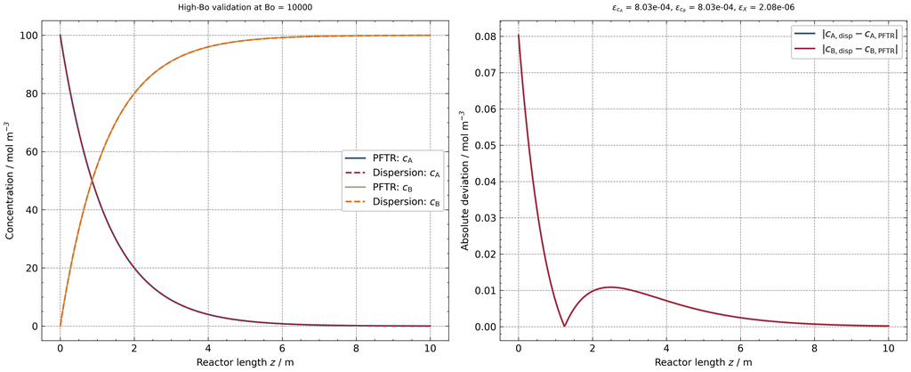

```python
# Plot validation of the dispersion model against the PFTR limit at high Bodenstein number

fig, axes = plt.subplots(1, 2, figsize=(12, 5), dpi=500)

# Concentration profiles
axes[0].plot(z_validation, c_A_pftr_validation, label="PFTR: $c_{\\mathrm{A}}$")
axes[0].plot(z_validation, c_A_disp_validation, "--", label="Dispersion: $c_{\\mathrm{A}}$")
axes[0].plot(z_validation, c_B_pftr_validation, label="PFTR: $c_{\\mathrm{B}}$")
axes[0].plot(z_validation, c_B_disp_validation, "--", label="Dispersion: $c_{\\mathrm{B}}$")

axes[0].set_xlabel("Reactor length $z$ / m")
axes[0].set_ylabel("Concentration / mol m$^{-3}$")
axes[0].set_title(f"High-Bo validation at Bo = {Bo_validation:.0f}")
axes[0].grid(True)
axes[0].legend()

# Absolute profile deviations
axes[1].plot(
    z_validation,
    np.abs(c_A_disp_validation - c_A_pftr_validation),
    label="$|c_{\\mathrm{A,disp}} - c_{\\mathrm{A,PFTR}}|$",
)
axes[1].plot(
    z_validation,
    np.abs(c_B_disp_validation - c_B_pftr_validation),
    label="$|c_{\\mathrm{B,disp}} - c_{\\mathrm{B,PFTR}}|$",
)

axes[1].set_xlabel("Reactor length $z$ / m")
axes[1].set_ylabel("Absolute deviation / mol m$^{-3}$")
axes[1].set_title(
    f"$\\varepsilon_{{c_A}}$ = {eps_c_A:.2e}, "
    f"$\\varepsilon_{{c_B}}$ = {eps_c_B:.2e}, "
    f"$\\varepsilon_X$ = {eps_X:.2e}"
)
axes[1].grid(True)
axes[1].legend()

fig.tight_layout()
plt.show()
```

**Figure 1:** Validation of the axial dispersion model against the ideal PFTR at $Bo = 10000$.

The figure shows the comparison between the ideal PFTR solution and the axial dispersion model at a high Bodenstein number. A high $Bo$ corresponds to a low axial dispersion coefficient and therefore to weak axial backmixing. In this limit, the non-ideal tubular reactor is expected to approach ideal plug-flow behaviour.

This expected behaviour is clearly visible in the concentration profiles. The profiles of $c_{\mathrm{A}}$ and $c_{\mathrm{B}}$ from the dispersion model almost overlap with the corresponding PFTR profiles over the full reactor length. The absolute deviations remain very small compared to the inlet concentration, with maximum relative errors of $\varepsilon_{c_{\mathrm{A}}} = 8.03 \cdot 10^{-4}$ and $\varepsilon_{c_{\mathrm{B}}} = 8.03 \cdot 10^{-4}$. The outlet conversion deviation is even smaller with $\varepsilon_X = 2.08 \cdot 10^{-6}$.

The largest concentration deviation occurs close to the reactor inlet, where the Danckwerts boundary condition introduces a small difference between the inlet concentration and the concentration directly inside the dispersed reactor. Downstream, the deviations decrease and the dispersion model follows the PFTR solution closely. This confirms that the implemented boundary value problem correctly reproduces the ideal PFTR limit when axial backmixing becomes negligible.

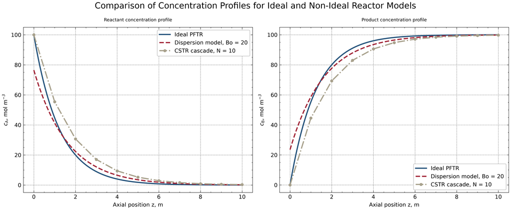

```python
# Concentration profile comparison of ideal PFTR, non-ideal dispersion model and CSTR cascade

z_cascade = np.linspace(0.0, L, N_CSTR + 1)             # equivalent axial positions, m

fig, axes = plt.subplots(1, 2, figsize=(12, 5), dpi = 500)

# Concentration profile of A
axes[0].plot(
    z_pftr,
    c_A_pftr,
    linewidth=2,
    label="Ideal PFTR"
)

axes[0].plot(
    z_disp,
    c_A_disp,
    linewidth=2,
    linestyle="--",
    label=f"Dispersion model, Bo = {Bo:.0f}"
)

axes[0].plot(
    z_cascade,
    c_A_cascade,
    marker="o",
    linestyle="-.",
    linewidth=2,
    label=f"CSTR cascade, N = {N_CSTR}"
)

axes[0].set_xlabel("Axial position z, m")
axes[0].set_ylabel(r"$c_{\mathrm{A}}$, mol m$^{-3}$")
axes[0].set_title("Reactant concentration profile")
axes[0].grid(True)
axes[0].legend()


# Concentration profile of B
axes[1].plot(
    z_pftr,
    c_B_pftr,
    linewidth=2,
    label="Ideal PFTR"
)

axes[1].plot(
    z_disp,
    c_B_disp,
    linewidth=2,
    linestyle="--",
    label=f"Dispersion model, Bo = {Bo:.0f}"
)

axes[1].plot(
    z_cascade,
    c_B_cascade,
    marker="o",
    linestyle="-.",
    linewidth=2,
    label=f"CSTR cascade, N = {N_CSTR}"
)

axes[1].set_xlabel("Axial position z, m")
axes[1].set_ylabel(r"$c_{\mathrm{B}}$, mol m$^{-3}$")
axes[1].set_title("Product concentration profile")
axes[1].grid(True)
axes[1].legend()

fig.suptitle("Comparison of Concentration Profiles for Ideal and Non-Ideal Reactor Models", fontsize=14)
fig.tight_layout()
plt.show()
```

**Figure 2:** Comparison of reactant and product concentration profiles for the ideal PFTR, the axial dispersion model at $Bo = 20$, and a CSTR cascade with $N = 10$.

The figure compares the concentration profiles of $c_{\mathrm{A}}$ and $c_{\mathrm{B}}$ for the three implemented reactor models. In all cases, component $\mathrm{A}$ is consumed and component $\mathrm{B}$ is formed according to the reaction stoichiometry. Therefore, $c_{\mathrm{A}}$ decreases along the reactor, while $c_{\mathrm{B}}$ increases. Since the reaction is first order, the concentration change is strongest near the inlet, where $c_{\mathrm{A}}$ and therefore the reaction rate are highest.

The ideal PFTR represents the reference case without axial backmixing. Its inlet concentrations are fixed directly by the initial conditions in Eq. (25). Therefore, the PFTR profile starts exactly at $c_{\mathrm{A},0} = 100~\mathrm{mol\ m^{-3}}$ and $c_{\mathrm{B},0} = 0~\mathrm{mol\ m^{-3}}$. The concentration profiles then change continuously along the reactor according to the plug-flow balance in Eq. (24).

The axial dispersion model differs from the ideal PFTR because axial backmixing is included through the second derivative term in Eq. (27). For $Bo = 20$, the dispersion coefficient is large enough to visibly influence the inlet region. In contrast to the PFTR, the dispersion model does not impose the feed concentration directly as $c_i(0)$. Instead, the Danckwerts boundary condition in Eq. (31) balances the upstream convective molar flow with the convective and dispersive fluxes at the reactor boundary. Therefore, $c_{\mathrm{A}}(0)$ and $c_{\mathrm{B}}(0)$ describe the reactor-side boundary concentrations and can differ from the upstream feed concentrations.

This explains why the dispersion model starts with a lower $c_{\mathrm{A}}$ and a higher $c_{\mathrm{B}}$ than the PFTR. Due to axial dispersion, product-rich fluid is transported slightly upstream, which decreases the local reactant concentration and increases the local product concentration at the reactor inlet. This effect is strongest near the inlet and becomes less relevant further downstream. Toward the outlet, the dispersion and PFTR profiles approach similar final concentrations because the reaction is nearly complete.

The CSTR cascade shows a different type of non-ideal behaviour. According to Eq. (34), the total residence time is divided into $N$ ideally mixed tanks, and Eq. (35) is solved for each tank. The plotted cascade values are therefore discrete outlet concentrations after each tank, shown at equivalent axial positions. The first point corresponds to the feed before the first tank, while the following points represent the tank outlet concentrations.

Compared with the PFTR, the CSTR cascade keeps $c_{\mathrm{A}}$ higher and $c_{\mathrm{B}}$ lower over most of the reactor length. This is caused by ideal mixing inside each tank. Fresh reactant is mixed with already reacted fluid, which lowers the average reactant concentration driving the reaction compared with ideal plug flow. Consequently, the cascade with $N = 10$ approaches the final conversion more slowly than the PFTR and the dispersion model.

Overall, the figure shows that the dispersion model at $Bo = 20$ is still relatively close to plug-flow behaviour, but already shows visible inlet backmixing. The CSTR cascade with $N = 10$ represents stronger mixed-flow behaviour and therefore deviates more clearly from the ideal PFTR over the reactor length.

```python
# Table 1 and plot: inlet concentration of dispersion model for varied Bodenstein numbers

Bo_values = np.array([1, 2, 5, 10, 20, 50, 100, 200, 500, 1000, 2000, 5000, 1e4])

c_A_z0_values = []
c_A_zL_values = []
X_A_values = []
D_ax_values = []

# Initial BVP guess
c_A_guess = np.linspace(c_in[0], 0.5 * c_in[0], z_mesh.size)   # mol m^-3
c_B_guess = c_in[0] - c_A_guess                                # mol m^-3
dc_A_dz_guess = np.gradient(c_A_guess, z_mesh)                 # mol m^-4
dc_B_dz_guess = np.gradient(c_B_guess, z_mesh)                 # mol m^-4

y_guess = np.vstack((c_A_guess, dc_A_dz_guess, c_B_guess, dc_B_dz_guess))

for Bo_i in Bo_values:
    D_ax_i = u * L / Bo_i                                      # axial dispersion coefficient, m^2 s^-1

    sol_Bo = solve_bvp(
        fun=lambda z, y: dispersion_model(
            z=z,
            y=y,
            k=k,
            n=n,
            stoich_coeff=stoich_coeff,
            u=u,
            D_ax=D_ax_i,
        ),
        bc=lambda ya, yb: dispersion_boundary_conditions(
            ya=ya,
            yb=yb,
            c_in=c_in,
            u_0=u_0,
            A_0=A_0,
            u=u,
            A=A,
            D_ax=D_ax_i,
        ),
        x=z_mesh,
        y=y_guess,
        tol=tol_bvp,
        max_nodes=max_nodes_bvp,
    )

    if not sol_Bo.success:
        raise RuntimeError(f"Bo = {Bo_i:.3e}: {sol_Bo.message}")

    c_A_z0 = sol_Bo.sol(0.0)[0]                                # c_A at z = 0, mol m^-3
    c_A_zL = sol_Bo.sol(L)[0]                                  # c_A at z = L, mol m^-3
    X_A = 1.0 - c_A_zL / c_A_in                                # outlet conversion, -

    D_ax_values.append(D_ax_i)
    c_A_z0_values.append(c_A_z0)
    c_A_zL_values.append(c_A_zL)
    X_A_values.append(X_A)

    y_guess = sol_Bo.sol(z_mesh)                               # next initial guess

# Markdown table
df_Bo = pd.DataFrame({
    r"$Bo$ / $\mathrm{-}$": [f"{Bo_i:.0f}" for Bo_i in Bo_values],
    r"$\mathcal{D}$ / $\mathrm{m^{2}\,s^{-1}}$": [f"{D_i:.4e}" for D_i in D_ax_values],
    r"$c_{\mathrm{A}}(z=0)$ / $\mathrm{mol\,m^{-3}}$": [f"{c_i:.4f}" for c_i in c_A_z0_values],
    r"$c_{\mathrm{A}}(z=L)$ / $\mathrm{mol\,m^{-3}}$": [f"{c_i:.4f}" for c_i in c_A_zL_values],
    r"$X_{\mathrm{A}}$ / $\mathrm{-}$": [f"{X_i:.5f}" for X_i in X_A_values],
})

display(Markdown("**Table 1:** Dispersion-model inlet and outlet concentrations for varied Bodenstein numbers."))
display(Markdown(df_Bo.to_markdown(index=False)))
```

**Table 1:** Dispersion-model inlet and outlet concentrations for varied Bodenstein numbers.

| $Bo$ / $\mathrm{-}$ | $\mathcal{D}$ / $\mathrm{m^{2}\,s^{-1}}$ | $c_{\mathrm{A}}(z=0)$ / $\mathrm{mol\,m^{-3}}$ | $c_{\mathrm{A}}(z=L)$ / $\mathrm{mol\,m^{-3}}$ | $X_{\mathrm{A}}$ / $\mathrm{-}$ |
| --- | --- | --- | --- | --- |
| 1 | 12.434 | 29.7008 | 4.6755 | 0.95324 |
| 2 | 6.217 | 38.9704 | 2.7339 | 0.97266 |
| 5 | 2.4868 | 53.6692 | 1.0483 | 0.98952 |
| 10 | 1.2434 | 65.4979 | 0.4542 | 0.99546 |
| 20 | 0.6217 | 76.4794 | 0.2014 | 0.99799 |
| 50 | 0.24868 | 87.6443 | 0.0855 | 0.99914 |
| 100 | 0.12434 | 93.0383 | 0.056 | 0.99944 |
| 200 | 0.06217 | 96.2729 | 0.0433 | 0.99957 |
| 500 | 0.024868 | 98.4413 | 0.0364 | 0.99964 |
| 1000 | 0.012434 | 99.2084 | 0.0343 | 0.99966 |
| 2000 | 0.006217 | 99.6011 | 0.0332 | 0.99967 |
| 5000 | 0.0024868 | 99.8397 | 0.0326 | 0.99967 |
| 10000 | 0.0012434 | 99.9197 | 0.0324 | 0.99968 |

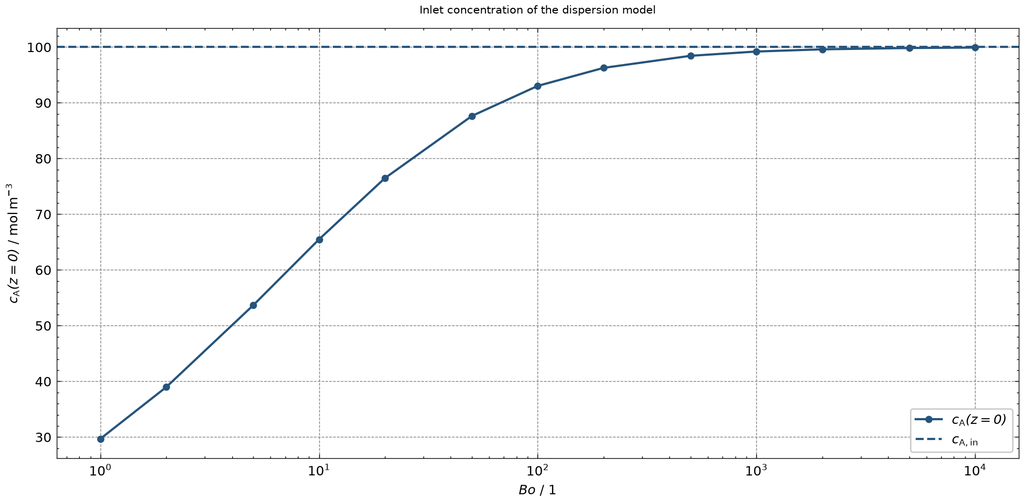

```python
# Plot
fig, ax = plt.subplots(figsize=(10, 5), dpi = 200)

ax.plot(Bo_values, c_A_z0_values, marker="o", label=r"$c_{\mathrm{A}}(z=0)$")
ax.axhline(c_A_in, linestyle="--", label=r"$c_{\mathrm{A,in}}$")

ax.set_xscale("log")
ax.set_xlabel(r"$Bo$ / $\mathrm{1}$")
ax.set_ylabel(r"$c_{\mathrm{A}}(z=0)$ / $\mathrm{mol\,m^{-3}}$")
ax.set_title(r"Inlet concentration of the dispersion model")
ax.grid(True)
ax.legend()

plt.tight_layout()
plt.show()
```

**Figure 3:** Influence of the Bodenstein number on the reactor-side inlet concentration $c_{\mathrm{A}}(z=0)$ of the axial dispersion model.

Figure 3 and Table 1 quantify the inlet effect that was already visible in Figure 2. In the axial dispersion model, the concentration at $z = 0$ is not fixed directly to the feed concentration. Instead, the Danckwerts boundary condition in Eq. (31) balances the upstream convective inlet flow with the convective and dispersive fluxes at the reactor boundary. Therefore, $c_{\mathrm{A}}(z = 0)$ represents the reactor-side inlet concentration and may differ from the feed concentration $c_{\mathrm{A},0}$.

The trend clearly depends on the Bodenstein number. At low $Bo$, the axial dispersion coefficient is high according to Eq. (22). This leads to strong axial backmixing, so reactant-depleted liquid from inside the reactor is transported back toward the inlet. As a result, $c_{\mathrm{A}}(z = 0)$ is significantly lower than the feed concentration. For example, at very low $Bo$, the table shows a strong reduction of the reactor-side inlet concentration compared with $c_{\mathrm{A},0} = 100~\mathrm{mol\ m^{-3}}$.

With increasing $Bo$, the dispersion coefficient decreases and axial backmixing becomes weaker. Consequently, $c_{\mathrm{A}}(z = 0)$ increases and approaches the feed concentration. At high $Bo$, the curve nearly reaches the dashed reference line, which corresponds to the PFTR limit. In this limit, the dispersive inlet flux becomes negligible and the reactor-side concentration becomes almost identical to the imposed feed concentration.

This confirms the interpretation from Figure 2: the different inlet concentration of the dispersion model is not a numerical error, but a direct consequence of axial dispersion combined with the Danckwerts inlet boundary condition. The deviation is relevant for low and intermediate $Bo$, while it becomes negligible for high $Bo$.

## 3.5 Comparison between Ideal PFTR Behaviour and Varied Backmixing of the Dispersion Model

The ideal PFTR is compared with the axial dispersion model for different degrees of backmixing. The reaction order is fixed to $n = 1$ so that the influence of axial dispersion can be evaluated independently of changes in reaction kinetics.

The ideal PFTR represents the limiting case without axial backmixing. In contrast, the dispersion model includes axial transport in addition to convection. The strength of backmixing is varied through the Bodenstein number. The investigated values are:

\begin{equation*} Bo = [1,\ 10,\ 100,\ 1000,\ 10000] \end{equation*}

For each Bodenstein number, the axial dispersion coefficient is recalculated according to Eq. (22). A low $Bo$ corresponds to a high dispersion coefficient and therefore strong axial backmixing. A high $Bo$ corresponds to a low dispersion coefficient and therefore weak axial backmixing.

The comparison is performed using the concentration profiles of $c_{\mathrm{A}}$ and $c_{\mathrm{B}}$ along the reactor. The ideal PFTR profile is used as reference. For increasing $Bo$, the dispersion model is expected to approach the PFTR profile. At low $Bo$, stronger axial backmixing should smooth the concentration gradients and cause a larger deviation from plug-flow behaviour, especially close to the reactor inlet where the Danckwerts boundary condition allows the reactor-side inlet concentration to differ from the upstream feed concentration.

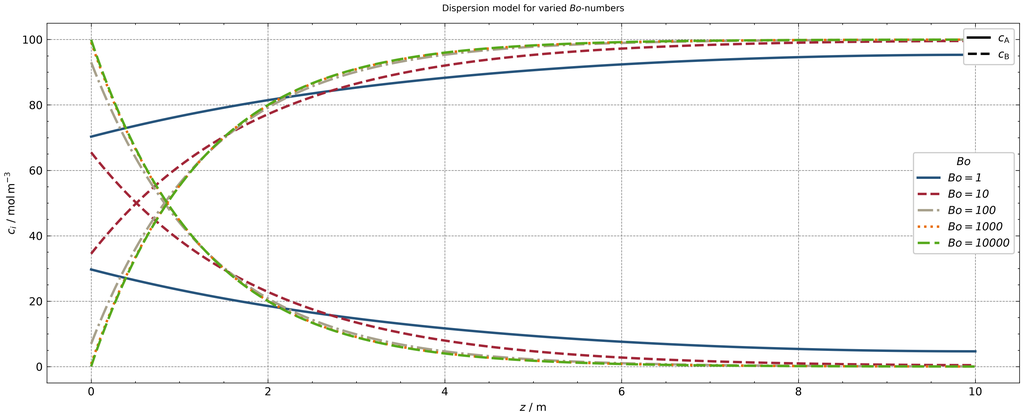

```python
# Comparison of dispersion model concentration profiles for varied Bodenstein numbers
# Same Bodenstein number = same color and same linestyle

from matplotlib.lines import Line2D

Bo_values = [1, 10, 100, 1000, 10000]               # Bodenstein numbers, -
n_compare = 1.0                                     # reaction order for this study, -

linestyles = ["-", "--", "-.", ":", (0, (5, 2))]
colors = ["C0", "C1", "C2", "C3", "C4"]

fig, ax = plt.subplots(figsize=(12, 5), dpi=500)

# Initial BVP guess
c_A_guess = np.linspace(c_in[0], 0.5 * c_in[0], z_mesh.size)   # guessed c_A profile, mol m^-3
c_B_guess = c_in[0] - c_A_guess                                # guessed c_B profile, mol m^-3
dc_A_dz_guess = np.gradient(c_A_guess, z_mesh)                 # guessed dc_A/dz, mol m^-4
dc_B_dz_guess = np.gradient(c_B_guess, z_mesh)                 # guessed dc_B/dz, mol m^-4

y_guess = np.vstack((c_A_guess, dc_A_dz_guess, c_B_guess, dc_B_dz_guess))

for Bo_i, ls, color in zip(Bo_values, linestyles, colors):
    D_ax_i = u * L / Bo_i                                      # axial dispersion coefficient, m^2 s^-1

    sol_Bo = solve_bvp(
        fun=lambda z, y: dispersion_model(
            z=z,
            y=y,
            k=k,
            n=n_compare,
            stoich_coeff=stoich_coeff,
            u=u,
            D_ax=D_ax_i,
        ),
        bc=lambda ya, yb: dispersion_boundary_conditions(
            ya=ya,
            yb=yb,
            c_in=c_in,
            u_0=u_0,
            A_0=A_0,
            u=u,
            A=A,
            D_ax=D_ax_i,
        ),
        x=z_mesh,
        y=y_guess,
        tol=tol_bvp,
        max_nodes=max_nodes_bvp,
    )

    if not sol_Bo.success:
        raise RuntimeError(f"Bo = {Bo_i:.0f}: {sol_Bo.message}")

    c_Bo = sol_Bo.sol(z_eval)
    c_A_Bo = c_Bo[0]                                           # concentration profile of A, mol m^-3
    c_B_Bo = c_Bo[2]                                           # concentration profile of B, mol m^-3

    ax.plot(z_eval, c_A_Bo, color=color, linestyle=ls, linewidth=2)
    ax.plot(z_eval, c_B_Bo, color=color, linestyle=ls, linewidth=2)

    y_guess = sol_Bo.sol(z_mesh)                               # use converged solution as next guess

ax.set_xlabel(r"$z$ / $\mathrm{m}$")
ax.set_ylabel(r"$c_i$ / $\mathrm{mol\,m^{-3}}$")
ax.set_title(r"Dispersion model for varied $Bo$-numbers")
ax.grid(True)

# Legend for Bodenstein numbers
bo_handles = [
    Line2D([0], [0], color=color, linestyle=ls, lw=2, label=fr"$Bo = {Bo_i}$")
    for Bo_i, ls, color in zip(Bo_values, linestyles, colors)
]
legend_bo = ax.legend(handles=bo_handles, title=r"$Bo$", loc="center right")
ax.add_artist(legend_bo)

# Legend for species
species_handles = [
    Line2D([0], [0], color="black", linestyle="-", lw=2, label=r"$c_{\mathrm{A}}$"),
    Line2D([0], [0], color="black", linestyle="--", lw=2, label=r"$c_{\mathrm{B}}$"),
]
ax.legend(handles=species_handles, loc="upper right")

plt.tight_layout()
plt.show()
```

**Figure 4:** Concentration profiles of the axial dispersion model for varied Bodenstein numbers at first-order reaction kinetics.

The Bodenstein number controls the degree of axial backmixing. At low $Bo$, the axial dispersion coefficient is high and backmixing is strong. This is visible for $Bo = 1$, where the concentration gradients are strongly smoothed. The reactor-side inlet concentration of $c_{\mathrm{A}}$ is already much lower than the feed concentration, while $c_{\mathrm{B}}$ is already present at the inlet. This behaviour is caused by axial backmixing and the Danckwerts inlet boundary condition, as discussed for Figure 3.

With increasing $Bo$, the dispersion coefficient decreases and the profiles become steeper near the inlet. The reactor-side inlet concentrations approach the feed concentrations, and the profiles shift toward plug-flow behaviour. For $Bo = 1000$ and $Bo = 10000$, the curves are nearly identical, indicating that further reduction of axial dispersion has only a small effect. These cases represent the practical approach to the ideal PFTR limit.

Overall, the figure confirms that low $Bo$ values lead to strong backmixing and broad concentration profiles, whereas high $Bo$ values reduce axial dispersion and recover plug-flow-like behaviour.

## 3.6 Comparison between Ideal PFTR and CSTR Cascade Model

The ideal PFTR is compared with the CSTR cascade model. The PFTR represents continuous plug-flow behaviour without axial backmixing, while the CSTR cascade approximates the reactor by a finite number of ideally mixed vessels in series.

Each individual CSTR is assumed to be ideally mixed. Therefore, strong mixing occurs within each tank. As the number of tanks increases, the residence time distribution of the cascade becomes narrower and the overall reactor behaviour approaches the ideal PFTR limit. The cascade model can therefore be interpreted as a discretized approximation of plug flow.

The investigated numbers of CSTRs are:

\begin{equation*} N = [10,\ 20,\ 50,\ 100,\ 200] \end{equation*}

For each value of $N$, the total residence time is divided equally between the tanks. The concentration profiles of $c_{\mathrm{A}}$ and $c_{\mathrm{B}}$ are evaluated at the outlet of each tank and plotted at equivalent axial positions along the reactor. The ideal PFTR profile is used as reference. With increasing $N$, the CSTR cascade is expected to approach the PFTR profile, while low $N$ values show stronger deviations due to the stronger influence of ideal mixing within each tank.

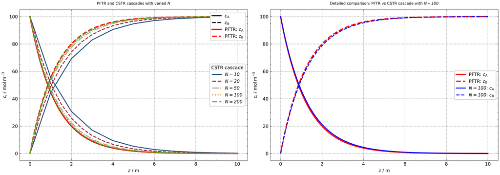

```python
# Comparison of ideal PFTR and CSTR cascade model
# Left: PFTR and varied CSTR cascades
# Right: detailed comparison of PFTR and CSTR cascade with N = 100

N_values = [10, 20, 50, 100, 200]                  # number of CSTRs in cascade, -
linestyles = ["-", "--", "-.", ":", (0, (5, 2))]
colors = ["C0", "C1", "C2", "C3", "C4"]

N_compare = 100                                   # number of CSTRs for detailed comparison, -
tau_CSTR_compare = tau_PFTR / N_compare            # space time of one CSTR, s

fig, axes = plt.subplots(1, 2, figsize=(14, 5), dpi=500)

# Left plot: PFTR and varied CSTR cascades
axes[0].plot(z_pftr, c_A_pftr, color="red", linestyle="-", linewidth=2.5)
axes[0].plot(z_pftr, c_B_pftr, color="red", linestyle="--", linewidth=2.5)

for N_i, ls, color in zip(N_values, linestyles, colors):
    tau_CSTR_i = tau_PFTR / N_i                      # space time of one CSTR, s

    c_cascade_i = solve_cstr_cascade(
        c_in=c_in,
        N_CSTR=N_i,
        tau_CSTR=tau_CSTR_i,
        k=k,
        n=n,
        stoich_coeff=stoich_coeff,
    )

    z_cascade_i = np.linspace(0.0, L, N_i + 1)      # equivalent axial positions, m
    c_A_cascade_i = c_cascade_i[:, 0]               # concentration profile of A, mol m^-3
    c_B_cascade_i = c_cascade_i[:, 1]               # concentration profile of B, mol m^-3

    axes[0].plot(z_cascade_i, c_A_cascade_i, color=color, linestyle=ls, linewidth=1.8)
    axes[0].plot(z_cascade_i, c_B_cascade_i, color=color, linestyle=ls, linewidth=1.8)

axes[0].set_xlabel(r"$z$ / $\mathrm{m}$")
axes[0].set_ylabel(r"$c_i$ / $\mathrm{mol\,m^{-3}}$")
axes[0].set_title(r"PFTR and CSTR cascades with varied $N$")
axes[0].grid(True)

cascade_handles = [
    Line2D([0], [0], color=color, linestyle=ls, lw=2, label=fr"$N = {N_i}$")
    for N_i, ls, color in zip(N_values, linestyles, colors)
]
legend_N = axes[0].legend(handles=cascade_handles, title=r"CSTR cascade", loc="center right")
axes[0].add_artist(legend_N)

style_handles_left = [
    Line2D([0], [0], color="black", linestyle="-", lw=2, label=r"$c_{\mathrm{A}}$"),
    Line2D([0], [0], color="black", linestyle="--", lw=2, label=r"$c_{\mathrm{B}}$"),
    Line2D([0], [0], color="red", linestyle="-", lw=2.5, label=r"PFTR: $c_{\mathrm{A}}$"),
    Line2D([0], [0], color="red", linestyle="--", lw=2.5, label=r"PFTR: $c_{\mathrm{B}}$"),
]
axes[0].legend(handles=style_handles_left, loc="upper right")

# Right plot: PFTR vs CSTR cascade with N = 1000
c_cascade_compare = solve_cstr_cascade(
    c_in=c_in,
    N_CSTR=N_compare,
    tau_CSTR=tau_CSTR_compare,
    k=k,
    n=n,
    stoich_coeff=stoich_coeff,
)

z_cascade_compare = np.linspace(0.0, L, N_compare + 1)   # equivalent axial positions, m
c_A_cascade_compare = c_cascade_compare[:, 0]            # concentration profile of A, mol m^-3
c_B_cascade_compare = c_cascade_compare[:, 1]            # concentration profile of B, mol m^-3

axes[1].plot(z_pftr, c_A_pftr, color="red", linestyle="-", linewidth=2.5)
axes[1].plot(z_pftr, c_B_pftr, color="red", linestyle="--", linewidth=2.5)

axes[1].plot(z_cascade_compare, c_A_cascade_compare, color="blue", linestyle="-", linewidth=1.8)
axes[1].plot(z_cascade_compare, c_B_cascade_compare, color="blue", linestyle="--", linewidth=1.8)

axes[1].set_xlabel(r"$z$ / $\mathrm{m}$")
axes[1].set_ylabel(r"$c_i$ / $\mathrm{mol\,m^{-3}}$")
axes[1].set_title(r"Detailed comparison: PFTR vs CSTR cascade with $N = 100$")
axes[1].grid(True)

style_handles_right = [
    Line2D([0], [0], color="red", linestyle="-", lw=2.5, label=r"PFTR: $c_{\mathrm{A}}$"),
    Line2D([0], [0], color="red", linestyle="--", lw=2.5, label=r"PFTR: $c_{\mathrm{B}}$"),
    Line2D([0], [0], color="blue", linestyle="-", lw=1.8, label=fr"$N = {N_compare}$: $c_{{\mathrm{{A}}}}$"),
    Line2D([0], [0], color="blue", linestyle="--", lw=1.8, label=fr"$N = {N_compare}$: $c_{{\mathrm{{B}}}}$"),
]
axes[1].legend(handles=style_handles_right, loc="best")

plt.tight_layout()
plt.show()
```

**Figure 5:** Comparison of concentration profiles for the ideal PFTR and CSTR cascades with varied numbers of ideally mixed tanks.

The figure shows how the CSTR cascade approaches the ideal PFTR when the number of tanks is increased. In the left plot, the concentration profiles of $c_{\mathrm{A}}$ and $c_{\mathrm{B}}$ are shown for different cascade sizes. The ideal PFTR is used as the reference case.

For low numbers of tanks, especially $N=10$ and $N=20$, the cascade clearly deviates from the PFTR profile. The reactant concentration $c_{\mathrm{A}}$ remains higher over a large part of the reactor length, while the product concentration $c_{\mathrm{B}}$ increases more slowly. This is caused by the ideal mixing assumption inside each CSTR. The concentration in each tank is uniform, so fresh reactant is immediately mixed with already converted fluid. As a result, the concentration gradient is less sharp than in the PFTR.

With increasing $N$, the residence time per tank becomes smaller and the discretization of the reactor becomes finer. The concentration change per tank decreases, and the cascade behaves more like a continuous plug-flow reactor. This trend is visible for $N=50$, $N=100$, and $N=200$, where the cascade profiles increasingly overlap with the PFTR solution.

The right plot shows a detailed comparison between the PFTR and the cascade with $N=100$. In this case, the profiles are already very close. Small deviations are still visible, but the overall behaviour is nearly plug-flow-like. Therefore, a high number of CSTRs can approximate the ideal PFTR well, while a small number of tanks represents stronger backmixing and stronger deviation from ideal plug flow.

Overall, the figure confirms that the CSTR cascade is a discretized approximation of the PFTR. The larger the number of ideally mixed vessels, the weaker the influence of mixing in each individual vessel on the total reactor behaviour.

## 3.7 Comparison between Dispersion model and CSTR cascade

**Table 2:** Comparison of the dispersion model at $Bo = 20$ and the CSTR cascade with $N = 10$ at three axial positions.

| $z/L$ | $z \,/\, \mathrm{m}$ | $c_{\mathrm{A},\mathrm{disp}} \,/\, \mathrm{mol\,m^{-3}}$ | $c_{\mathrm{A},\mathrm{cascade}} \,/\, \mathrm{mol\,m^{-3}}$ | $\Delta c_{\mathrm{A}} \,/\, \mathrm{mol\,m^{-3}}$ | $c_{\mathrm{B},\mathrm{disp}} \,/\, \mathrm{mol\,m^{-3}}$ | $c_{\mathrm{B},\mathrm{cascade}} \,/\, \mathrm{mol\,m^{-3}}$ | $\Delta c_{\mathrm{B}} \,/\, \mathrm{mol\,m^{-3}}$ |
| --- | --- | --- | --- | --- | --- | --- | --- |
| 0.25 | 2.50 | 16.4340 | 23.8725 | 7.4385 | 83.5660 | 76.1275 | -7.4385 |
| 0.50 | 5.00 | 3.5313 | 5.2302 | 1.6989 | 96.4687 | 94.7698 | -1.6989 |
| 1.00 | 10.00 | 0.2014 | 0.2736 | 0.0722 | 99.7986 | 99.7264 | -0.0722 |

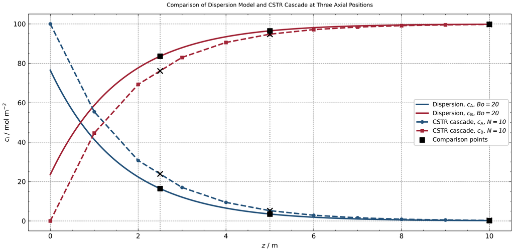

```python
# Table 2 and single-plot comparison of dispersion model and CSTR cascade
# Comparison basis: Bo = 20 and N = 10

from IPython.display import Markdown, display

Bo_compare = 20.0                         # Bodenstein number, -
N_compare = 10                            # number of CSTRs, -

D_ax_compare = u * L / Bo_compare         # axial dispersion coefficient, m^2 s^-1
tau_tank_compare = (L / u) / N_compare    # residence time per CSTR, s


# Solve dispersion model for Bo = 20
c_A_guess = np.interp(z_mesh, z_pftr, c_A_pftr)      # mol m^-3
c_B_guess = np.interp(z_mesh, z_pftr, c_B_pftr)      # mol m^-3
r_guess = reaction_rate(c_A_guess, k, n)             # mol m^-3 s^-1

y_guess_compare = np.zeros((4, z_mesh.size))
y_guess_compare[0, :] = c_A_guess
y_guess_compare[1, :] = stoich_coeff[0] * r_guess / u
y_guess_compare[2, :] = c_B_guess
y_guess_compare[3, :] = stoich_coeff[1] * r_guess / u

sol_disp_compare = solve_bvp(
    fun=lambda z, y: dispersion_model(z, y, k, n, stoich_coeff, u, D_ax_compare),
    bc=lambda ya, yb: dispersion_boundary_conditions(
        ya, yb, c_in, u_0, A_0, u, A, D_ax_compare
    ),
    x=z_mesh,
    y=y_guess_compare,
    tol=tol_bvp,
    max_nodes=max_nodes_bvp,
)

if not sol_disp_compare.success:
    raise RuntimeError(sol_disp_compare.message)

y_disp_compare = sol_disp_compare.sol(z_eval)

c_A_disp_compare = y_disp_compare[0]       # mol m^-3
c_B_disp_compare = y_disp_compare[2]       # mol m^-3


# Solve CSTR cascade for N = 10
c_cascade_compare = solve_cstr_cascade(
    c_in=c_in,
    N_CSTR=N_compare,
    tau_CSTR=tau_tank_compare,
    k=k,
    n=n,
    stoich_coeff=stoich_coeff,
)

# Include feed point if only tank outlet concentrations are returned
if c_cascade_compare.shape[0] == N_compare:
    c_cascade_compare = np.vstack((c_in, c_cascade_compare))

z_cascade_compare = np.linspace(0.0, L, c_cascade_compare.shape[0])


# Three comparison points
z_compare_points = np.array([0.25 * L, 0.50 * L, 1.00 * L])     # m
z_compare_fraction = z_compare_points / L                       # -

c_A_disp_points = np.interp(z_compare_points, z_eval, c_A_disp_compare)
c_B_disp_points = np.interp(z_compare_points, z_eval, c_B_disp_compare)

c_A_cascade_points = np.interp(
    z_compare_points,
    z_cascade_compare,
    c_cascade_compare[:, 0],
)

c_B_cascade_points = np.interp(
    z_compare_points,
    z_cascade_compare,
    c_cascade_compare[:, 1],
)

delta_c_A = c_A_cascade_points - c_A_disp_points
delta_c_B = c_B_cascade_points - c_B_disp_points


# Markdown table with LaTeX headers that render correctly in Jupyter

table_md = (
    f"**Table 2:** Comparison of the dispersion model at $Bo = {Bo_compare:.0f}$ "
    f"and the CSTR cascade with $N = {N_compare}$ at three axial positions.\n\n"
    "| $z/L$ | $z \\,/\\, \\mathrm{m}$ | "
    "$c_{\\mathrm{A},\\mathrm{disp}} \\,/\\, \\mathrm{mol\\,m^{-3}}$ | "
    "$c_{\\mathrm{A},\\mathrm{cascade}} \\,/\\, \\mathrm{mol\\,m^{-3}}$ | "
    "$\\Delta c_{\\mathrm{A}} \\,/\\, \\mathrm{mol\\,m^{-3}}$ | "
    "$c_{\\mathrm{B},\\mathrm{disp}} \\,/\\, \\mathrm{mol\\,m^{-3}}$ | "
    "$c_{\\mathrm{B},\\mathrm{cascade}} \\,/\\, \\mathrm{mol\\,m^{-3}}$ | "
    "$\\Delta c_{\\mathrm{B}} \\,/\\, \\mathrm{mol\\,m^{-3}}$ |\n"
    "|---:|---:|---:|---:|---:|---:|---:|---:|\n"
)

for i in range(len(z_compare_points)):
    table_md += (
        f"| {z_compare_fraction[i]:.2f} "
        f"| {z_compare_points[i]:.2f} "
        f"| {c_A_disp_points[i]:.4f} "
        f"| {c_A_cascade_points[i]:.4f} "
        f"| {delta_c_A[i]:.4f} "
        f"| {c_B_disp_points[i]:.4f} "
        f"| {c_B_cascade_points[i]:.4f} "
        f"| {delta_c_B[i]:.4f} |\n"
    )

display(Markdown(table_md))


# Single plot with A and B
fig, ax = plt.subplots(figsize=(10, 5), dpi=500)

# Dispersion model
ax.plot(
    z_eval,
    c_A_disp_compare,
    color=iciw_color_cycle[0],
    linestyle=linestyles[0],
    linewidth=2,
    label=rf"Dispersion, $c_{{\mathrm{{A}}}}$, $Bo = {Bo_compare:.0f}$",
)

ax.plot(
    z_eval,
    c_B_disp_compare,
    color=iciw_color_cycle[1],
    linestyle=linestyles[0],
    linewidth=2,
    label=rf"Dispersion, $c_{{\mathrm{{B}}}}$, $Bo = {Bo_compare:.0f}$",
)

# CSTR cascade
ax.plot(
    z_cascade_compare,
    c_cascade_compare[:, 0],
    color=iciw_color_cycle[0],
    linestyle=linestyles[1],
    marker=markers[0],
    linewidth=2,
    label=rf"CSTR cascade, $c_{{\mathrm{{A}}}}$, $N = {N_compare}$",
)

ax.plot(
    z_cascade_compare,
    c_cascade_compare[:, 1],
    color=iciw_color_cycle[1],
    linestyle=linestyles[1],
    marker=markers[1],
    linewidth=2,
    label=rf"CSTR cascade, $c_{{\mathrm{{B}}}}$, $N = {N_compare}$",
)

# Mark three comparison positions
for z_i in z_compare_points:
    ax.axvline(
        z_i,
        color="gray",
        linestyle=":",
        linewidth=1,
    )

ax.scatter(
    z_compare_points,
    c_A_disp_points,
    color="black",
    marker="s",
    s=45,
    zorder=5,
    label="Comparison points",
)

ax.scatter(
    z_compare_points,
    c_B_disp_points,
    color="black",
    marker="s",
    s=45,
    zorder=5,
)

ax.scatter(
    z_compare_points,
    c_A_cascade_points,
    color="black",
    marker="x",
    s=55,
    zorder=5,
)

ax.scatter(
    z_compare_points,
    c_B_cascade_points,
    color="black",
    marker="x",
    s=55,
    zorder=5,
)

ax.set_xlabel(r"$z$ / m")
ax.set_ylabel(r"$c_i$ / mol m$^{-3}$")
ax.set_title("Comparison of Dispersion Model and CSTR Cascade at Three Axial Positions")
ax.grid(True)
ax.legend(fontsize=8)

fig.tight_layout()
plt.show()
```

**Figure 6:** Comparison of concentration profiles from the axial dispersion model at $Bo = 20$ and the CSTR cascade with $N = 10$. Solid lines represent the dispersion model, while dashed lines with markers represent the CSTR cascade. The vertical dotted lines indicate the three comparison positions  
at $z/L = 0.25,\;0.50,\;\mathrm{and}\;1.00$.

The figure compares the axial dispersion model with the CSTR cascade at a similar degree of residence time spreading. The comparison is based on $Bo = 20$ for the dispersion model and $N = 10$ for the CSTR cascade, using the approximation $N \approx Bo/2$ as a practical reference.

Both models show the expected decrease of $c_{\mathrm{A}}$ and increase of $c_{\mathrm{B}}$ along the reactor. However, the CSTR cascade predicts a slower conversion than the dispersion model. At the first comparison point, $z/L = 0.25$, the CSTR cascade gives a higher reactant concentration and a lower product concentration. This indicates stronger mixed-flow behaviour in the cascade, because each tank is ideally mixed and therefore reduces the local concentration driving force compared with the more continuous axial dispersion model.

The difference between both models decreases further downstream. At $z/L = 0.50$, the deviations are already smaller, and at the outlet they are nearly negligible. This is caused by the high overall conversion in both models. Once most of component $\mathrm{A}$ has reacted, the remaining concentration difference between the models becomes small.

Overall, the comparison shows that a CSTR cascade with $N = 10$ can reproduce the general trend of the dispersion model at $Bo = 20$, but it does not match the concentration profile exactly. The cascade gives slightly lower conversion at intermediate reactor positions. Therefore, the relation  
$N \approx Bo/2$ is useful as an approximate comparison basis, but it does not imply identical local concentration profiles.

## 4. Residence time distribution

## 4.1 Ideal PFTR

For the ideal PFTR, axial backmixing is neglected. All fluid elements move through the reactor with the same residence time. Therefore, the residence time distribution is infinitely narrow and the cumulative distribution function changes from zero to one at the nominal residence time.

\begin{equation} \tau = \frac{L}{u} \tag{49} \end{equation}

\begin{equation} F(t) = \left\{ \begin{array}{ll} 0, & t < \tau \\ 1, & t \geq \tau \end{array} \right. \tag{50} \end{equation}

In dimensionless form, the residence time is expressed as:

\begin{equation} \Theta = \frac{t}{\tau} \tag{51} \end{equation}

Thus, the ideal PFTR shows an instantaneous outlet response at $\Theta = 1$. This represents the limiting case without residence time spreading.

## 4.2 Residence Time Distribution of the Non-Ideal Tubular Reactor

For the non-ideal tubular reactor, the residence time distribution is calculated from the dynamic response of an inert tracer. Since the tracer does not react, the model contains only convective and dispersive transport. The dynamic axial dispersion balance is a partial differential equation:

\begin{equation} \frac{\partial c_{\mathrm{T}}}{\partial t} = \mathcal{D} \frac{\partial^2 c_{\mathrm{T}}}{\partial z^2} - u \frac{\partial c_{\mathrm{T}}}{\partial z} \tag{52} \end{equation}

Eq. (52) cannot be solved directly with `solve_bvp`, because it contains derivatives with respect to both time and reactor length. Therefore, the time derivative is approximated by a backward finite difference:

\begin{equation} \frac{\partial c_{\mathrm{T}}}{\partial t} \approx \frac{c_{\mathrm{T}}(t_i,z)-c_{\mathrm{T}}(t_{i-1},z)}{\Delta t} \tag{53} \end{equation}

Inserting Eq. (53) into Eq. (52) gives a boundary value problem in the axial coordinate $z$ for each time step. To solve this second-order equation with `solve_bvp`, it is rewritten as a first-order system:

\begin{equation} \frac{\mathrm{d} c_{\mathrm{T}}}{\mathrm{d} z} = y \tag{54} \end{equation}

\begin{equation} \frac{\mathrm{d} y}{\mathrm{d} z} = \frac{1}{\mathcal{D}} \left( \frac{c_{\mathrm{T}}(t_i,z)-c_{\mathrm{T}}(t_{i-1},z)}{\Delta t} + u y \right) \tag{55} \end{equation}

The initial condition for the tracer concentration inside the reactor is:

\begin{equation} c_{\mathrm{T}}(t=0,z) = 0 \tag{56} \end{equation}

The inlet boundary condition is formulated as a Danckwerts condition. It balances the upstream convective tracer flow with the convective and dispersive transport at the reactor inlet:

\begin{equation} \left. \frac{\partial c_{\mathrm{T}}}{\partial z} \right|_{z=0} = \frac{u A c_{\mathrm{T}}(0,t_i)-u_0 A_0 c_{\mathrm{T,in}}(t_i)} {A \mathcal{D}} \tag{57} \end{equation}

At the reactor outlet, a zero-gradient condition is applied:

\begin{equation} \left. \frac{\partial c_{\mathrm{T}}}{\partial z} \right|_{z=L} = 0 \tag{58} \end{equation}

The balance equations are implemented in the function `dispersion_model_tracer`, while the corresponding boundary conditions are implemented in the function `bc_tracer`. For every time step, the previous tracer concentration profile is used in Eq. (55), and the new profile is calculated by solving the resulting boundary value problem. The outlet tracer concentration is then used to determine the cumulative residence time distribution.

The tracer inlet concentration is set to $1~\mathrm{mol\ m^{-3}}$. The time discretization uses $250$ steps.

```python
# Tracer RTD parameters for the axial dispersion model

c_T_in_step = 1.0                 # tracer inlet step concentration, mol m^-3

tau_tracer = L / u                # reactor space time used for tracer response, s
t_end_tracer = 5.0 * tau_tracer   # final tracer simulation time, s
n_time_tracer = 250               # number of time points, -

t_tracer = np.linspace(0.0, t_end_tracer, n_time_tracer)   # time grid, s
dt_tracer = t_tracer[1] - t_tracer[0]                      # constant time step, s

z_tracer = z_mesh.copy()          # axial grid for tracer BVP, m

print(f"c_T_in_step = {c_T_in_step:.2f} mol m^-3")
print(f"tau_tracer = {tau_tracer:.4f} s")
print(f"t_end_tracer = {t_end_tracer:.4f} s")
print(f"dt_tracer = {dt_tracer:.4e} s")
print(f"z nodes = {len(z_tracer)}")
```

```
c_T_in_step = 1.00 mol m^-3
tau_tracer = 8.0425 s
t_end_tracer = 40.2124 s
dt_tracer = 1.6150e-01 s
z nodes = 250
```

```python
def dispersion_model_tracer(z, y, c_T_previous, z_previous, dt, u, D_ax):
    """
    Define the dynamic axial dispersion model for an inert tracer.

    The time derivative is approximated by a backward finite difference.
    For each time step, the resulting equation is solved as a BVP in z.

    State vector
    ------------
    y[0] = c_T
        Tracer concentration, mol m^-3.
    y[1] = dc_T/dz
        Axial tracer concentration gradient, mol m^-4.

    Inputs
    ------
    z : np.ndarray
        Axial reactor coordinate used by solve_bvp, m.
    y : np.ndarray
        State matrix with shape (2, len(z)).
    c_T_previous : np.ndarray
        Tracer concentration profile from the previous time step,
        mol m^-3.
    z_previous : np.ndarray
        Axial grid of the previous tracer profile, m.
    dt : float
        Time-step size, s.
    u : float
        Superficial velocity in the reactor, m s^-1.
    D_ax : float
        Axial dispersion coefficient, m^2 s^-1.

    Output
    ------
    dy_dz : np.ndarray
        Derivatives of the state vector with shape (2, len(z)).
        Rows are [dc_T/dz, d2c_T/dz2].
    """
    c_T = y[0]                                      # tracer concentration, mol m^-3
    dc_T_dz = y[1]                                  # tracer concentration gradient, mol m^-4

    c_T_old = np.interp(z, z_previous, c_T_previous)

    d2c_T_dz2 = ((c_T - c_T_old) / dt + u * dc_T_dz) / D_ax

    dy_dz = np.vstack((dc_T_dz, d2c_T_dz2))

    return dy_dz


def bc_tracer(ya, yb, c_T_in, u_0, A_0, u, A, D_ax):
    """
    Define the Danckwerts inlet boundary condition and the zero-gradient
    outlet boundary condition for the tracer dispersion model.

    Inputs
    ------
    ya : np.ndarray
        State vector at reactor inlet z = 0.
        ya = [c_T, dc_T/dz].
    yb : np.ndarray
        State vector at reactor outlet z = L.
        yb = [c_T, dc_T/dz].
    c_T_in : float
        Tracer inlet concentration in the upstream section, mol m^-3.
    u_0 : float
        Upstream superficial velocity, m s^-1.
    A_0 : float
        Upstream cross-sectional area, m^2.
    u : float
        Superficial velocity in the reactor, m s^-1.
    A : float
        Reactor cross-sectional area, m^2.
    D_ax : float
        Axial dispersion coefficient, m^2 s^-1.

    Output
    ------
    bc : np.ndarray
        Boundary-condition residuals [bc_in, bc_out].
        The BVP solver searches for bc = [0, 0].
    """
    bc_in = ya[1] - (u * A * ya[0] - u_0 * A_0 * c_T_in) / (A * D_ax)
    bc_out = yb[1]                                  # zero-gradient outlet, mol m^-4

    bc = np.array([bc_in, bc_out])

    return bc
```

The tracer dispersion model is solved on the defined time grid. For each time step, the previous tracer profile is used to approximate the time derivative and to provide the initial guess for the next boundary value problem. The resulting tracer concentration profile is stored as $c_{\mathrm{T}}(z,t_i)$.

The outlet tracer concentration is taken at the reactor outlet:

\begin{equation} c_{\mathrm{T,out}}(t_i) = c_{\mathrm{T}}(L,t_i) \tag{59} \end{equation}

From the outlet response, the cumulative residence time distribution is calculated as:

\begin{equation} F(t_i) = \frac{c_{\mathrm{T,out}}(t_i)}{c_{\mathrm{T,in}}} \tag{60} \end{equation}

The residence time distribution is obtained by numerical differentiation of the cumulative distribution. In the implementation, this derivative is evaluated with `np.gradient`:

\begin{equation} E(t_i) \approx \left. \frac{\mathrm{d}F}{\mathrm{d}t} \right|_{t=t_i} \tag{61} \end{equation}

For comparison between reactor models, the time axis is converted into the dimensionless residence time:

\begin{equation} \Theta_i = \frac{t_i}{\tau} \tag{62} \end{equation}

The dimensionless RTD function is calculated by scaling $E(t)$ with the mean residence time:

\begin{equation} E(\Theta_i) = \tau E(t_i) \tag{63} \end{equation}

The numerical quality of the RTD calculation is checked by integrating the E-function. For a correctly normalized residence time distribution, both integrals should approach one:

\begin{equation} \int_0^\infty E(t) \ \mathrm{d}t \approx 1 \qquad \int_0^\infty E(\Theta) \ \mathrm{d}\Theta \approx 1 \tag{64} \end{equation}

The final value of $F(t)$ should also approach one, because a step tracer input with constant inlet concentration eventually leads to the same tracer concentration at the reactor outlet.

```python
# Solve tracer dispersion model and calculate F- and E-functions
# Uses variables already defined in this notebook:
# t_tracer, n_time_tracer, z_tracer, dt_tracer, c_T_in_step, tau_tracer
# u, u_0, A, A_0, D_ax, tol_bvp, max_nodes_bvp

c_T_profiles = np.zeros((n_time_tracer, z_tracer.size))      # tracer profiles, mol m^-3
dc_T_dz_profiles = np.zeros((n_time_tracer, z_tracer.size))  # tracer gradients, mol m^-4
c_T_out_disp = np.zeros(n_time_tracer)                       # outlet tracer concentration, mol m^-3

# Initial tracer profile inside the reactor
c_T_previous = np.zeros_like(z_tracer)                       # initial c_T(z,0), mol m^-3

# Initial BVP guess
y_guess = np.zeros((2, z_tracer.size))
y_guess[0, :] = c_T_previous                                # c_T guess, mol m^-3
y_guess[1, :] = 0.0                                         # dc_T/dz guess, mol m^-4

for i, t_i in enumerate(t_tracer):
    c_T_in_current = c_T_in_step                            # step input, mol m^-3

    sol_tracer = solve_bvp(
        fun=lambda z, y: dispersion_model_tracer(
            z, y, c_T_previous, z_tracer, dt_tracer, u, D_ax
        ),
        bc=lambda ya, yb: bc_tracer(
            ya, yb, c_T_in_current, u_0, A_0, u, A, D_ax
        ),
        x=z_tracer,
        y=y_guess,
        tol=tol_bvp,
        max_nodes=max_nodes_bvp,
    )

    if not sol_tracer.success:
        raise RuntimeError(f"Tracer BVP failed at t = {t_i:.4f} s: {sol_tracer.message}")

    y_current = sol_tracer.sol(z_tracer)

    c_T_profiles[i, :] = y_current[0]
    dc_T_dz_profiles[i, :] = y_current[1]
    c_T_out_disp[i] = y_current[0, -1]

    # Use current solution as previous profile and next initial guess
    c_T_previous = y_current[0].copy()
    y_guess = y_current.copy()

# Dimensional F- and E-functions
F_t_disp = c_T_out_disp / c_T_in_step                       # cumulative RTD function, -
E_t_disp = np.gradient(F_t_disp, t_tracer)                  # RTD function, s^-1

# Dimensionless F- and E-functions
theta_disp = t_tracer / tau_tracer                          # dimensionless time, -
F_theta_disp = F_t_disp                                     # dimensionless cumulative RTD, -
E_theta_disp = tau_tracer * E_t_disp                        # dimensionless RTD, -

# Numerical checks
area_E_t = np.trapezoid(E_t_disp, t_tracer)                     # integral of E(t), -
area_E_theta = np.trapezoid(E_theta_disp, theta_disp)           # integral of E(theta), -

print(f"Final F(t) = {F_t_disp[-1]:.5f}")
print(f"Integral E(t) dt = {area_E_t:.5f}")
print(f"Integral E(theta) dtheta = {area_E_theta:.5f}")
print(f"Outlet tracer concentration = {c_T_out_disp[-1]:.5f} mol m^-3")
```

```
Final F(t) = 1.00000
Integral E(t) dt = 1.00000
Integral E(theta) dtheta = 1.00000
Outlet tracer concentration = 1.00000 mol m^-3
```

## 4.3 Residence Time Distribution in a CSTR Cascade

The residence time distribution of the ideal CSTR and the CSTR cascade is calculated from the dynamic response to an inert step tracer. The tracer does not react and is only transported by the liquid flow through the ideally mixed vessels. First, the outlet tracer concentration is calculated with `solve_ivp`. The F- and E-functions are then obtained from the normalized outlet response.

For one ideal CSTR, the tracer balance is:

\begin{equation} \frac{\mathrm{d} c_{\mathrm{T}}}{\mathrm{d} t} = \frac{c_{\mathrm{T,in}} - c_{\mathrm{T}}}{\tau} \tag{65} \end{equation}

For a cascade of $N$ ideal CSTRs, the total residence time is divided equally between all tanks:

\begin{equation} \tau_N = \frac{\tau}{N} \tag{66} \end{equation}

The tracer balances for the cascade are:

\begin{equation} \frac{\mathrm{d} c_{\mathrm{T},1}}{\mathrm{d} t} = \frac{c_{\mathrm{T,in}} - c_{\mathrm{T},1}}{\tau_N} \qquad \frac{\mathrm{d} c_{\mathrm{T},m}}{\mathrm{d} t} = \frac{c_{\mathrm{T},m-1} - c_{\mathrm{T},m}}{\tau_N} \quad m = 2,\dots,N \tag{67} \end{equation}

The outlet tracer concentration of the last vessel is used to calculate the cumulative residence time distribution:

\begin{equation} F(t) = \frac{c_{\mathrm{T,out}}(t)}{c_{\mathrm{T,in}}} \tag{68} \end{equation}

The E-function is obtained by numerical differentiation:

\begin{equation} E(t) = \frac{\mathrm{d}F(t)}{\mathrm{d}t} \tag{69} \end{equation}

The dimensionless functions are calculated with:

\begin{equation} \Theta = \frac{t}{\tau} \qquad E(\Theta) = \tau E(t) \tag{70} \end{equation}

For $N = 1$, the cascade corresponds to one ideal CSTR. With increasing $N$, the residence time distribution becomes narrower and approaches ideal PFTR behaviour.

```python
# Residence time distribution of one ideal CSTR

c_T_in_cstr = 1.0                    # tracer inlet step concentration, mol m^-3
tau_total_rtd = L / u                # total mean residence time, s

t_end_cstr = 8.0 * tau_total_rtd     # final simulation time, s
n_time_cstr = 500                    # number of time points, -
t_cstr = np.linspace(0.0, t_end_cstr, n_time_cstr)

def cstr_tracer_model(t, c_T):
    """
    Dynamic tracer balance for one ideal CSTR.

    Input
    -----
    t : float
        Time, s.
    c_T : np.ndarray
        Tracer concentration in the CSTR, mol m^-3.

    Output
    ------
    dc_T_dt : list
        Time derivative of tracer concentration, mol m^-3 s^-1.
    """
    dc_T_dt = (c_T_in_cstr - c_T[0]) / tau_total_rtd
    return [dc_T_dt]


sol_cstr_rtd = solve_ivp(
    fun=cstr_tracer_model,
    t_span=(t_cstr[0], t_cstr[-1]),
    y0=[0.0],
    t_eval=t_cstr,
    rtol=rtol_ivp,
    atol=atol_ivp,
)

if not sol_cstr_rtd.success:
    raise RuntimeError(sol_cstr_rtd.message)

# F- and E-functions
c_T_out_cstr = sol_cstr_rtd.y[0]                         # outlet tracer concentration, mol m^-3

F_t_cstr = c_T_out_cstr / c_T_in_cstr                    # cumulative RTD function, -
E_t_cstr = np.gradient(F_t_cstr, t_cstr)                 # RTD function, s^-1

theta_cstr = t_cstr / tau_total_rtd                      # dimensionless time, -
F_theta_cstr = F_t_cstr                                  # dimensionless cumulative RTD, -
E_theta_cstr = tau_total_rtd * E_t_cstr                  # dimensionless RTD, -

# Numerical checks
area_E_t_cstr = np.trapezoid(E_t_cstr, t_cstr)
area_E_theta_cstr = np.trapezoid(E_theta_cstr, theta_cstr)

print(f"CSTR final F(t) = {F_t_cstr[-1]:.5f}")
print(f"CSTR integral E(t) dt = {area_E_t_cstr:.5f}")
print(f"CSTR integral E(theta) dtheta = {area_E_theta_cstr:.5f}")
print(f"CSTR outlet tracer concentration = {c_T_out_cstr[-1]:.5f} mol m^-3")
```

```
CSTR final F(t) = 0.99966
CSTR integral E(t) dt = 0.99966
CSTR integral E(theta) dtheta = 0.99966
CSTR outlet tracer concentration = 0.99966 mol m^-3
```

```python
# Residence time distribution of a CSTR cascade

N_cascade_rtd = N_CSTR                       # number of CSTRs in cascade, -
tau_tank_rtd = tau_total_rtd / N_cascade_rtd # residence time per tank, s

t_end_cascade = 8.0 * tau_total_rtd          # final simulation time, s
n_time_cascade = 500                         # number of time points, -
t_cascade = np.linspace(0.0, t_end_cascade, n_time_cascade)

def cstr_cascade_tracer_model(t, c_T):
    """
    Dynamic tracer balances for a CSTR cascade.

    Input
    -----
    t : float
        Time, s.
    c_T : np.ndarray
        Tracer concentrations in all tanks, mol m^-3.

    Output
    ------
    dc_T_dt : np.ndarray
        Time derivatives of tracer concentrations, mol m^-3 s^-1.
    """
    dc_T_dt = np.zeros_like(c_T)

    dc_T_dt[0] = (c_T_in_cstr - c_T[0]) / tau_tank_rtd

    for m in range(1, N_cascade_rtd):
        dc_T_dt[m] = (c_T[m - 1] - c_T[m]) / tau_tank_rtd

    return dc_T_dt


sol_cascade_rtd = solve_ivp(
    fun=cstr_cascade_tracer_model,
    t_span=(t_cascade[0], t_cascade[-1]),
    y0=np.zeros(N_cascade_rtd),
    t_eval=t_cascade,
    rtol=rtol_ivp,
    atol=atol_ivp,
)

if not sol_cascade_rtd.success:
    raise RuntimeError(sol_cascade_rtd.message)

# F- and E-functions
c_T_out_cascade = sol_cascade_rtd.y[-1]                  # outlet tracer concentration, mol m^-3

F_t_cascade = c_T_out_cascade / c_T_in_cstr              # cumulative RTD function, -
E_t_cascade = np.gradient(F_t_cascade, t_cascade)        # RTD function, s^-1

theta_cascade = t_cascade / tau_total_rtd                # dimensionless time, -
F_theta_cascade = F_t_cascade                            # dimensionless cumulative RTD, -
E_theta_cascade = tau_total_rtd * E_t_cascade            # dimensionless RTD, -

# Numerical checks
area_E_t_cascade = np.trapezoid(E_t_cascade, t_cascade)
area_E_theta_cascade = np.trapezoid(E_theta_cascade, theta_cascade)

print(f"CSTR cascade final F(t) = {F_t_cascade[-1]:.5f}")
print(f"CSTR cascade integral E(t) dt = {area_E_t_cascade:.5f}")
print(f"CSTR cascade integral E(theta) dtheta = {area_E_theta_cascade:.5f}")
print(f"CSTR cascade outlet tracer concentration = {c_T_out_cascade[-1]:.5f} mol m^-3")
```

```
CSTR cascade final F(t) = 1.00000
CSTR cascade integral E(t) dt = 1.00000
CSTR cascade integral E(theta) dtheta = 1.00000
CSTR cascade outlet tracer concentration = 1.00000 mol m^-3
```

The Residence-time distribution of the CSTR-cascade can now be visualized:

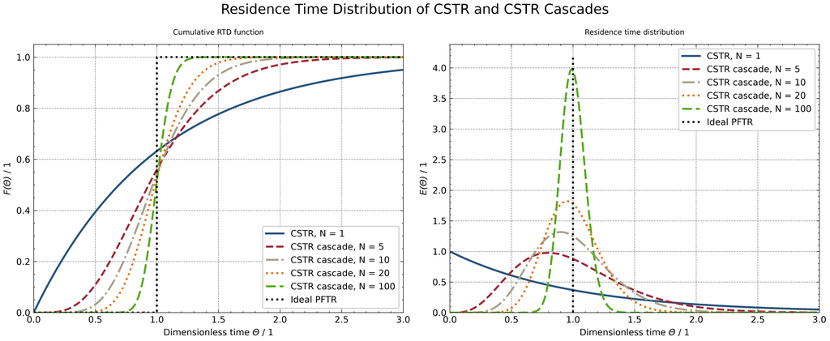

```python
# Plot RTD functions for one CSTR and CSTR cascades with different N

N_cascade_values = [5, 10, 20, 100]    # number of tanks in cascade, -
cascade_rtd_results = {}

for N_i in N_cascade_values:
    tau_tank_i = tau_total_rtd / N_i   # residence time per tank, s

    def cstr_cascade_tracer_model_N(t, c_T):
        dc_T_dt = np.zeros_like(c_T)
        dc_T_dt[0] = (c_T_in_cstr - c_T[0]) / tau_tank_i

        for m in range(1, N_i):
            dc_T_dt[m] = (c_T[m - 1] - c_T[m]) / tau_tank_i

        return dc_T_dt

    sol_cascade_i = solve_ivp(
        fun=cstr_cascade_tracer_model_N,
        t_span=(t_cascade[0], t_cascade[-1]),
        y0=np.zeros(N_i),
        t_eval=t_cascade,
        rtol=rtol_ivp,
        atol=atol_ivp,
    )

    if not sol_cascade_i.success:
        raise RuntimeError(f"CSTR cascade failed for N = {N_i}: {sol_cascade_i.message}")

    c_T_out_i = sol_cascade_i.y[-1]              # outlet tracer concentration, mol m^-3

    F_t_i = c_T_out_i / c_T_in_cstr              # cumulative RTD function, -
    E_t_i = np.gradient(F_t_i, t_cascade)        # RTD function, s^-1

    theta_i = t_cascade / tau_total_rtd          # dimensionless time, -
    F_theta_i = F_t_i                            # dimensionless cumulative RTD, -
    E_theta_i = tau_total_rtd * E_t_i            # dimensionless RTD, -

    cascade_rtd_results[N_i] = {
        "theta": theta_i,
        "F_theta": F_theta_i,
        "E_theta": E_theta_i,
    }


# Ideal PFTR reference for F(theta): step function
theta_pftr_ref = np.array([0.0, 1.0, 1.0, 3.0])
F_pftr_ref = np.array([0.0, 0.0, 1.0, 1.0])


fig, axes = plt.subplots(1, 2, figsize=(12, 5), dpi=500)

# F-functions
axes[0].plot(
    theta_cstr,
    F_theta_cstr,
    linewidth=2,
    color=iciw_color_cycle[0],
    linestyle=linestyles[0],
    label="CSTR, N = 1",
)

for i, N_i in enumerate(N_cascade_values):
    axes[0].plot(
        cascade_rtd_results[N_i]["theta"],
        cascade_rtd_results[N_i]["F_theta"],
        linewidth=2,
        color=iciw_color_cycle[(i + 1) % len(iciw_color_cycle)],
        linestyle=linestyles[(i + 1) % len(linestyles)],
        label=f"CSTR cascade, N = {N_i}",
    )

axes[0].plot(
    theta_pftr_ref,
    F_pftr_ref,
    color="black",
    linestyle=":",
    linewidth=2,
    label="Ideal PFTR",
)

axes[0].set_xlabel(r"Dimensionless time $\Theta$ / 1")
axes[0].set_ylabel(r"$F(\Theta)$ / 1")
axes[0].set_title("Cumulative RTD function")
axes[0].set_xlim(0.0, 3.0)
axes[0].set_ylim(0.0, 1.05)
axes[0].grid(True)
axes[0].legend()


# E-functions
axes[1].plot(
    theta_cstr,
    E_theta_cstr,
    linewidth=2,
    color=iciw_color_cycle[0],
    linestyle=linestyles[0],
    label="CSTR, N = 1",
)

for i, N_i in enumerate(N_cascade_values):
    axes[1].plot(
        cascade_rtd_results[N_i]["theta"],
        cascade_rtd_results[N_i]["E_theta"],
        linewidth=2,
        color=iciw_color_cycle[(i + 1) % len(iciw_color_cycle)],
        linestyle=linestyles[(i + 1) % len(linestyles)],
        label=f"CSTR cascade, N = {N_i}",
    )

# Ideal PFTR reference for E(theta): symbolic Dirac impulse
E_max_plot = max(
    np.max(E_theta_cstr),
    max(np.max(cascade_rtd_results[N_i]["E_theta"]) for N_i in N_cascade_values),
)

axes[1].plot(
    [1.0, 1.0],
    [0.0, 1.05 * E_max_plot],
    color="black",
    linestyle=":",
    linewidth=2,
    label="Ideal PFTR",
)

axes[1].set_xlabel(r"Dimensionless time $\Theta$ / 1")
axes[1].set_ylabel(r"$E(\Theta)$ / 1")
axes[1].set_title("Residence time distribution")
axes[1].set_xlim(0.0, 3.0)
axes[1].set_ylim(0.0, 1.1 * E_max_plot)
axes[1].grid(True)
axes[1].legend()

fig.suptitle("Residence Time Distribution of CSTR and CSTR Cascades", fontsize=14)
fig.tight_layout()
plt.show()
```

**Figure 7:** Residence time distribution of one ideal CSTR and CSTR cascades with different numbers of ideally mixed tanks. The left plot shows the cumulative RTD function $F(\Theta)$, while the right plot shows the corresponding residence time distribution $E(\Theta)$. The ideal PFTR is included as limiting reference, with a step change in $F(\Theta)$ and a symbolic impulse in $E(\Theta)$ at $\Theta = 1$.

Figure 7 compares the residence time distribution of one ideal CSTR with CSTR cascades containing different numbers of ideally mixed tanks. The ideal PFTR is included as the limiting reference case.

The left plot shows the cumulative RTD function $F(\Theta)$. For one ideal CSTR, $F(\Theta)$ starts to increase immediately at $\Theta = 0$ and approaches unity only slowly. This means that some fluid elements leave the reactor much earlier than the nominal residence time, while others remain in the reactor for much longer. This gradual transition is caused by complete mixing in the CSTR and indicates a broad residence time distribution.

The right plot shows the corresponding RTD function $E(\Theta)$. For one ideal CSTR, the curve starts at its maximum value and decreases continuously with increasing $\Theta$. This corresponds to the exponential residence time distribution of a single ideally mixed vessel. It shows that part of the tracer leaves the reactor very early, while another part remains inside much longer than the nominal residence time. This broad residence time spreading is characteristic of complete mixing in a single CSTR.

With increasing number of tanks, the RTD becomes narrower. For $N = 5$ and $N = 10$, early outlet response is still visible, but the distributions are already more concentrated around $\Theta = 1$ than for the single CSTR. The cumulative curves become steeper, and the maxima of the $E(\Theta)$ curves increase. At the same time, the peaks shift closer to $\Theta = 1$. This indicates that the spread of residence times decreases when the reactor volume is divided into more ideally mixed compartments.

For larger cascade numbers, especially $N = 20$ and $N = 100$, the RTD approaches ideal PFTR behaviour. The cumulative function becomes increasingly similar to the step function of the PFTR, and the $E(\Theta)$ function becomes narrow and high around $\Theta = 1$. In the limiting case of infinitely many CSTRs in series, the cascade would approach a PFTR, where all fluid elements have the same residence time.

Overall, the figure confirms that a CSTR cascade can be used as a discrete approximation of plug flow. A low number of tanks represents strong mixing and broad residence time spreading, while a high number of tanks reduces axial mixing effects and approaches the ideal PFTR limit.

## 4.4 Variation of the Bodenstein Number in the Residence Time Distribution

The influence of axial backmixing on the residence time distribution is investigated by varying the Bodenstein number. The studied values are:

\begin{equation*} Bo = [1,\ 5,\ 10,\ 50,\ 100,\ 1000,\ 10000] \end{equation*}

The Bodenstein number relates convective transport to axial dispersion. Low $Bo$ values correspond to strong axial dispersion and therefore strong backmixing, while high $Bo$ values correspond to weak axial dispersion and approach ideal PFTR behaviour. The RTD is calculated from the outlet response of an inert step tracer.

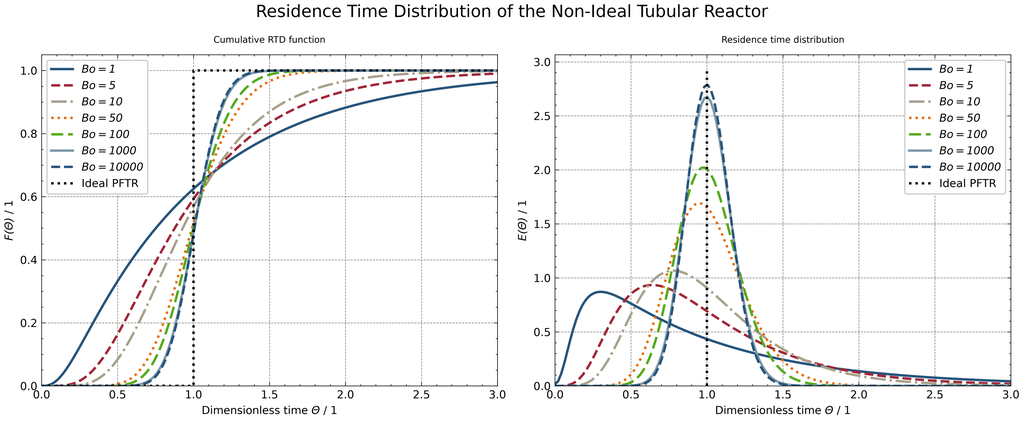

```python
# Chapter 4.4: Residence time distribution of the non-ideal tubular reactor
# F(theta) and E(theta) for varied Bodenstein numbers
# Figure layout adapted to Figure 7.

Bo_RTD_values = [1, 5, 10, 50, 100, 1000, 10000]     # Bodenstein numbers, -

linestyles = ["-", "--", "-.", ":", (0, (5, 2))]

try:
    colors_base = iciw_color_cycle
except NameError:
    colors_base = plt.rcParams["axes.prop_cycle"].by_key()["color"]

colors = [
    colors_base[i % len(colors_base)]
    for i in range(len(Bo_RTD_values))
]

theta = t_tracer / tau_tracer                         # dimensionless time, -

RTD_results = {}

fig, axes = plt.subplots(1, 2, figsize=(12, 5), dpi=500)

for i, Bo_i in enumerate(Bo_RTD_values):
    D_ax_i = u * L / Bo_i                             # axial dispersion coefficient, m^2 s^-1

    ls = linestyles[i % len(linestyles)]
    color = colors[i]
    label_i = fr"$Bo = {Bo_i:g}$"

    c_T_out = np.zeros(len(t_tracer))                 # outlet tracer signal, mol m^-3
    c_T_previous = np.zeros_like(z_tracer)            # initial tracer profile, mol m^-3

    for j in range(1, len(t_tracer)):
        dt = t_tracer[j] - t_tracer[j - 1]            # time-step size, s
        c_T_in = c_T_in_step                          # tracer step input, mol m^-3

        dc_T_dz_guess = np.gradient(c_T_previous, z_tracer)  # gradient guess, mol m^-4
        y_guess = np.vstack((c_T_previous, dc_T_dz_guess))

        sol_tracer = solve_bvp(
            fun=lambda z, y: dispersion_model_tracer(
                z=z,
                y=y,
                c_T_previous=c_T_previous,
                z_previous=z_tracer,
                dt=dt,
                u=u,
                D_ax=D_ax_i,
            ),
            bc=lambda ya, yb: bc_tracer(
                ya=ya,
                yb=yb,
                c_T_in=c_T_in,
                u_0=u_0,
                A_0=A_0,
                u=u,
                A=A,
                D_ax=D_ax_i,
            ),
            x=z_tracer,
            y=y_guess,
            tol=tol_bvp,
            max_nodes=max_nodes_bvp,
        )

        if not sol_tracer.success:
            raise RuntimeError(f"Bo = {Bo_i:g}: {sol_tracer.message}")

        c_T_current = sol_tracer.sol(z_tracer)[0]     # tracer profile, mol m^-3
        c_T_out[j] = c_T_current[-1]                  # outlet tracer concentration, mol m^-3
        c_T_previous = c_T_current.copy()

    F_theta = c_T_out / c_T_in_step                   # cumulative RTD function, -
    E_theta = tau_tracer * np.gradient(F_theta, t_tracer)  # dimensionless RTD, -

    RTD_results[Bo_i] = {
        "theta": theta,
        "F_theta": F_theta,
        "E_theta": E_theta,
        "D_ax": D_ax_i,
    }

    axes[0].plot(
        theta,
        F_theta,
        linewidth=2,
        color=color,
        linestyle=ls,
        label=label_i,
    )

    axes[1].plot(
        theta,
        E_theta,
        linewidth=2,
        color=color,
        linestyle=ls,
        label=label_i,
    )

# Ideal PFTR reference for F(theta): step function
theta_pftr_ref = np.array([0.0, 1.0, 1.0, 3.0])
F_pftr_ref = np.array([0.0, 0.0, 1.0, 1.0])

axes[0].plot(
    theta_pftr_ref,
    F_pftr_ref,
    color="black",
    linestyle=":",
    linewidth=2,
    label="Ideal PFTR",
)

# Ideal PFTR reference for E(theta): symbolic Dirac impulse
E_max_plot = max(
    np.max(RTD_results[Bo_i]["E_theta"])
    for Bo_i in Bo_RTD_values
)

axes[1].plot(
    [1.0, 1.0],
    [0.0, 1.05 * E_max_plot],
    color="black",
    linestyle=":",
    linewidth=2,
    label="Ideal PFTR",
)

# F-functions
axes[0].set_xlabel(r"Dimensionless time $\Theta$ / 1")
axes[0].set_ylabel(r"$F(\Theta)$ / 1")
axes[0].set_title("Cumulative RTD function")
axes[0].set_xlim(0.0, 3.0)
axes[0].set_ylim(0.0, 1.05)
axes[0].margins(y=0)
axes[0].grid(True)
axes[0].legend()

# E-functions
axes[1].set_xlabel(r"Dimensionless time $\Theta$ / 1")
axes[1].set_ylabel(r"$E(\Theta)$ / 1")
axes[1].set_title("Residence time distribution")
axes[1].set_xlim(0.0, 3.0)
axes[1].set_ylim(0.0, 1.1 * E_max_plot)
axes[1].margins(y=0)
axes[1].grid(True)
axes[1].legend()

fig.suptitle("Residence Time Distribution of the Non-Ideal Tubular Reactor", fontsize=14)
fig.tight_layout()
plt.show()
```

**Figure 8:** Residence time distribution of the non-ideal tubular reactor for varied Bodenstein numbers. The left plot shows the cumulative RTD function $F(\Theta)$, while the right plot shows the corresponding residence time distribution $E(\Theta)$. The ideal PFTR is included as limiting reference, with a step change in $F(\Theta)$ and a symbolic impulse in $E(\Theta)$ at $\Theta = 1$.

Figure 8 shows that the residence time distribution of the non-ideal tubular reactor is strongly affected by the Bodenstein number. The ideal PFTR is included as the limiting reference case.

The left plot shows the cumulative RTD function $F(\Theta)$. At low $Bo$, $F(\Theta)$ starts to increase well before $\Theta = 1$. This indicates that part of the tracer reaches the reactor outlet earlier than the nominal residence time. At the same time, $F(\Theta)$ approaches unity only slowly, which shows that another part of the tracer remains in the reactor for longer times. The broad transition is caused by strong axial dispersion and indicates significant backmixing.

The right plot shows the corresponding RTD function $E(\Theta)$. For low $Bo$, especially $Bo = 1$ and $Bo = 5$, the distributions are broad and show long tailing. This means that the tracer is spread over a wide residence time range. Physically, dispersive transport is large compared with convective transport, so the tracer is transported both downstream and upstream relative to ideal plug flow.

With increasing $Bo$, axial dispersion becomes weaker. The cumulative curves become steeper around $\Theta = 1$, and the corresponding $E(\Theta)$ curves become narrower and higher. At the same time, the tail of the distribution decreases. This shows that the residence times become more uniform and that more fluid elements leave the reactor close to the nominal residence time.

For $Bo = 1000$ and $Bo = 10000$, the RTD is already close to the ideal PFTR limit. The cumulative response becomes almost step-like, and the $E(\Theta)$ curve is concentrated around $\Theta = 1$. In the theoretical limit of $Bo \rightarrow \infty$, the RTD would approach the impulse function of an ideal PFTR, where all fluid elements have the same residence time.

Overall, the figure confirms the expected limiting behaviour of the axial dispersion model. Low $Bo$ values represent strong backmixing and broad residence time spreading, while high $Bo$ values reduce axial dispersion and approach ideal plug-flow behaviour.

## 4.5 Variation of the Reaction Order for Constant Numeric Rate Constant

The influence of the reaction order is investigated for the ideal PFTR and the axial dispersion model. The numerical value of the rate constant is kept constant for all reaction orders:

\begin{equation} k = 1 \tag{71} \end{equation}

The reaction rate is described by the power-law expression:

\begin{equation} r = k c_{\mathrm{A}}^n \tag{72} \end{equation}

The investigated reaction orders are:

\begin{equation} n = [0.5,\ 1.0,\ 1.5,\ 2.0] \tag{73} \end{equation}

For each reaction order, the ideal PFTR is solved as reference case without axial backmixing. The axial dispersion model is then solved for the previously investigated Bodenstein numbers:

\begin{equation} Bo = [1,\ 10,\ 100,\ 1000,\ 10000] \tag{74} \end{equation}

All reactor parameters, inlet concentrations, flow conditions and boundary conditions are kept constant. Only the reaction order is changed. The resulting concentration profiles of $c_{\mathrm{A}}$ and $c_{\mathrm{B}}$ are compared for each reaction order.

This variation is used as a numerical sensitivity study. Since the same numerical value of $k$ is used for all reaction orders, the initial reaction rate changes with $n$. Therefore, this comparison does not isolate the reaction order alone, but shows the combined effect of changing the reaction order and the effective kinetic strength. The results are still useful to illustrate how strongly the reactor response depends on the assumed rate law.

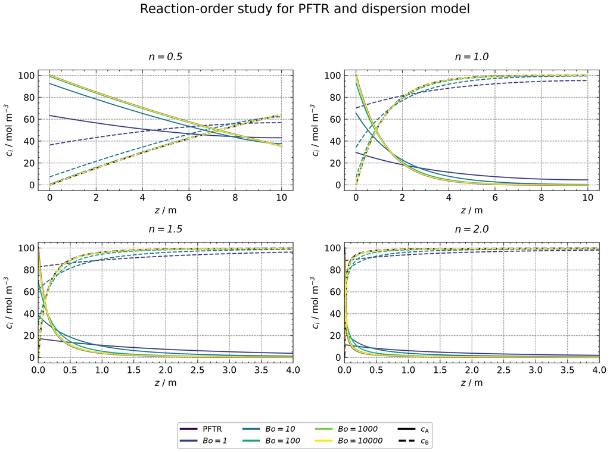

```python
# Reaction-order study for PFTR and dispersion model
# Concentration profiles only
# Case: same numeric value k = 1
# For n = 1.5 and n = 2.0, only 0 <= z <= 4 m is plotted

from matplotlib.lines import Line2D

reaction_orders = [0.5, 1.0, 1.5, 2.0]              # reaction orders, -
Bo_values_order = [1, 10, 100, 1000, 10000]         # plotted Bodenstein numbers, -
Bo_continuation = [10000, 3000, 1000, 300, 100, 30, 10, 3, 1]

k_same = 1.0                                        # same numeric value, unit depends on n
tol_bvp_order = 1e-3                                # relaxed tolerance for parameter study
max_nodes_bvp_order = 100000                        # maximum BVP mesh nodes, -
c_A_floor = 1e-8 * c_A_in                           # concentration floor, mol m^-3


def reaction_rate_stable(c_A, k_i, n_i):
    """
    Stable power-law reaction rate for arbitrary reaction order.
    The concentration floor avoids invalid fractional powers during BVP iterations.
    """
    c_A_eff = np.maximum(c_A, c_A_floor)
    return k_i * c_A_eff**n_i


def pftr_model_order(z, c, k_i, n_i, stoich_coeff, u):
    """
    Ideal PFTR model for A -> B with arbitrary reaction order.
    """
    r_i = reaction_rate_stable(c[0], k_i, n_i)

    dc_dz = np.zeros_like(c)
    dc_dz[0] = stoich_coeff[0] * r_i / u
    dc_dz[1] = stoich_coeff[1] * r_i / u

    return dc_dz


def dispersion_model_order(z, y, k_i, n_i, stoich_coeff, u, D_ax_i):
    """
    Axial dispersion model for A -> B with arbitrary reaction order.
    """
    c_A = y[0]
    dc_A_dz = y[1]
    dc_B_dz = y[3]

    r_i = reaction_rate_stable(c_A, k_i, n_i)

    d2c_A_dz2 = (u * dc_A_dz - stoich_coeff[0] * r_i) / D_ax_i
    d2c_B_dz2 = (u * dc_B_dz - stoich_coeff[1] * r_i) / D_ax_i

    return np.vstack((dc_A_dz, d2c_A_dz2, dc_B_dz, d2c_B_dz2))


def solve_pftr_for_order(k_i, n_i):
    """
    Solve the ideal PFTR for one reaction order.
    """
    sol = solve_ivp(
        fun=pftr_model_order,
        t_span=(0.0, L),
        y0=c_in,
        args=(k_i, n_i, stoich_coeff, u),
        t_eval=z_eval,
        method="RK45",
        rtol=rtol_ivp,
        atol=atol_ivp,
    )

    if not sol.success:
        raise RuntimeError(f"PFTR failed for n = {n_i}: {sol.message}")

    return sol.t, sol.y[0], sol.y[1]


def make_bvp_guess_from_profiles(z_source, c_A_source, c_B_source):
    """
    Create a BVP initial guess from concentration profiles.
    """
    c_A_guess = np.interp(z_mesh, z_source, c_A_source)
    c_B_guess = np.interp(z_mesh, z_source, c_B_source)

    dc_A_dz_guess = np.gradient(c_A_guess, z_mesh)
    dc_B_dz_guess = np.gradient(c_B_guess, z_mesh)

    return np.vstack((c_A_guess, dc_A_dz_guess, c_B_guess, dc_B_dz_guess))


def solve_dispersion_for_order(k_i, n_i, Bo_i, y_guess_i):
    """
    Solve the axial dispersion model for one reaction order and one Bo value.
    """
    D_ax_i = u * L / Bo_i                         # axial dispersion coefficient, m^2 s^-1

    sol = solve_bvp(
        fun=lambda z, y: dispersion_model_order(
            z,
            y,
            k_i,
            n_i,
            stoich_coeff,
            u,
            D_ax_i,
        ),
        bc=lambda ya, yb: dispersion_boundary_conditions(
            ya,
            yb,
            c_in,
            u_0,
            A_0,
            u,
            A,
            D_ax_i,
        ),
        x=z_mesh,
        y=y_guess_i,
        tol=tol_bvp_order,
        bc_tol=tol_bvp_order,
        max_nodes=max_nodes_bvp_order,
    )

    if not sol.success:
        raise RuntimeError(
            f"Dispersion model failed for n = {n_i}, Bo = {Bo_i}: {sol.message}"
        )

    y_eval_i = sol.sol(z_eval)
    y_mesh_i = sol.sol(z_mesh)

    return z_eval, y_eval_i[0], y_eval_i[2], y_mesh_i


def calculate_reaction_order_results_same_k():
    """
    Calculate PFTR and dispersion-model concentration profiles for k = 1.
    """
    results = {}

    for n_i in reaction_orders:
        z_pftr_i, c_A_pftr_i, c_B_pftr_i = solve_pftr_for_order(k_same, n_i)

        results[n_i] = {
            "k": k_same,
            "PFTR": {
                "z": z_pftr_i,
                "c_A": c_A_pftr_i,
                "c_B": c_B_pftr_i,
            },
            "dispersion": {},
        }

        # High Bo is close to the PFTR limit and gives a stable first BVP guess.
        y_guess_i = make_bvp_guess_from_profiles(z_pftr_i, c_A_pftr_i, c_B_pftr_i)

        for Bo_i in Bo_continuation:
            z_disp_i, c_A_disp_i, c_B_disp_i, y_mesh_i = solve_dispersion_for_order(
                k_i=k_same,
                n_i=n_i,
                Bo_i=Bo_i,
                y_guess_i=y_guess_i,
            )

            if Bo_i in Bo_values_order:
                results[n_i]["dispersion"][Bo_i] = {
                    "z": z_disp_i,
                    "c_A": c_A_disp_i,
                    "c_B": c_B_disp_i,
                }

            # Use current solution as guess for the next Bo value.
            y_guess_i = y_mesh_i.copy()

    return results


def plot_reaction_order_results_same_k(results):
    """
    Plot concentration profiles for all reaction orders.
    Each subplot contains PFTR and dispersion-model results for all plotted Bo values.
    Solid lines show c_A, dashed lines show c_B.
    For n = 1.5 and n = 2.0, only 0 <= z <= 4 m is shown.
    """
    fig, axes = plt.subplots(2, 2, figsize=(8.8, 6.2), dpi=300)
    axes = axes.flatten()

    model_labels = ["PFTR"] + [fr"$Bo = {Bo_i}$" for Bo_i in Bo_values_order]

    viridis = plt.get_cmap("viridis")
    model_colors = [
        viridis(i / (len(model_labels) - 1))
        for i in range(len(model_labels))
    ]

    for j, n_i in enumerate(reaction_orders):
        ax = axes[j]

        # PFTR
        ax.plot(
            results[n_i]["PFTR"]["z"],
            results[n_i]["PFTR"]["c_A"],
            color=model_colors[0],
            linestyle="-",
            linewidth=1.6,
        )

        ax.plot(
            results[n_i]["PFTR"]["z"],
            results[n_i]["PFTR"]["c_B"],
            color=model_colors[0],
            linestyle="--",
            linewidth=1.6,
        )

        # Dispersion model for varied Bo
        for i, Bo_i in enumerate(Bo_values_order):
            color_i = model_colors[i + 1]

            ax.plot(
                results[n_i]["dispersion"][Bo_i]["z"],
                results[n_i]["dispersion"][Bo_i]["c_A"],
                color=color_i,
                linestyle="-",
                linewidth=1.1,
            )

            ax.plot(
                results[n_i]["dispersion"][Bo_i]["z"],
                results[n_i]["dispersion"][Bo_i]["c_B"],
                color=color_i,
                linestyle="--",
                linewidth=1.1,
            )

        if n_i >= 1.5:
            ax.set_xlim(0.0, 4.0)

        ax.set_title(rf"$n = {n_i:.1f}$", fontsize=10)
        ax.set_xlabel(r"$z$ / m")
        ax.set_ylabel(r"$c_i$ / mol m$^{-3}$")
        ax.grid(True)

    model_handles = [
        Line2D(
            [0],
            [0],
            color=model_colors[i],
            linestyle="-",
            linewidth=2,
            label=model_labels[i],
        )
        for i in range(len(model_labels))
    ]

    species_handles = [
        Line2D([0], [0], color="black", linestyle="-", linewidth=2, label=r"$c_{\mathrm{A}}$"),
        Line2D([0], [0], color="black", linestyle="--", linewidth=2, label=r"$c_{\mathrm{B}}$"),
    ]

    fig.legend(
        handles=model_handles + species_handles,
        loc="lower center",
        ncol=4,
        fontsize=8,
        frameon=True,
        bbox_to_anchor=(0.5, -0.045),
    )

    fig.suptitle(r"Reaction-order study for PFTR and dispersion model", fontsize=13)
    fig.tight_layout(rect=[0.0, 0.08, 1.0, 0.94])
    plt.show()


results_same_k = calculate_reaction_order_results_same_k()
plot_reaction_order_results_same_k(results_same_k)
```

**Figure 9:** Influence of the reaction order on the concentration profiles of the ideal PFTR and the axial dispersion model for a constant numeric rate constant of $k = 1$. The four subplots show the reaction orders $n = 0.5$, $1.0$, $1.5$, and $2.0$. Solid lines represent $c_{\mathrm{A}}$, while dashed lines represent $c_{\mathrm{B}}$. The ideal PFTR is compared with dispersion-model results for different Bodenstein numbers. For $n = 1.5$ and $n = 2.0$, only the range from $z = 0$ to $z = 4~\mathrm{m}$ is shown because the reaction proceeds very rapidly near the reactor inlet.

Figure 9 shows the influence of the reaction order on the concentration profiles of the ideal PFTR and the axial dispersion model. The reaction orders $n = 0.5$, $1.0$, $1.5$, and $2.0$ are compared for a constant numerical rate constant of $k = 1$. For each reaction order, the PFTR is used as reference and the dispersion model is evaluated for different Bodenstein numbers.

For $n = 0.5$, the reaction rate depends only weakly on the concentration of $\mathrm{A}$. Therefore, the concentration profiles change comparatively smoothly along the reactor. The decrease of $c_{\mathrm{A}}$ and the corresponding increase of $c_{\mathrm{B}}$ occur over the full reactor length and are almost linear compared with the higher-order cases. Significant amounts of reactant remain at the outlet, showing that the reaction proceeds gradually and does not reach complete conversion within the investigated reactor length. The influence of the Bodenstein number is visible, but less pronounced than for higher reaction orders. Even under stronger backmixing, the reaction continues over a wide axial region because the rate does not collapse strongly when $c_{\mathrm{A}}$ decreases.

For $n = 1.0$, the concentration profiles become steeper. The first-order rate law leads to an exponential-type decrease of $c_{\mathrm{A}}$ in the PFTR. With increasing $Bo$, the dispersion-model profiles approach the PFTR profile. At low $Bo$, axial backmixing smooths the concentration gradients and causes a clear deviation from plug-flow behaviour. Reactant-depleted and product-rich liquid is transported upstream, which lowers the reactor-side inlet concentration of $\mathrm{A}$ and increases the inlet concentration of $\mathrm{B}$. Further downstream, the profiles approach each other because most of the reactant has already been converted.

For $n = 1.5$, the reaction becomes more localized near the reactor inlet. Since the rate depends more strongly on $c_{\mathrm{A}}$, high inlet concentrations lead to rapid conversion in the first part of the reactor. The effect of axial dispersion becomes especially relevant in this inlet region, where most of the reaction takes place. Low $Bo$ values cause a stronger spreading of the reaction zone, while high $Bo$ values approach the steep PFTR profile. Beyond the first part of the reactor, the remaining concentration changes are small.

For $n = 2.0$, the reaction rate is strongly concentration-dependent. The conversion occurs almost completely close to the reactor inlet for the PFTR and for high $Bo$ values. Once $c_{\mathrm{A}}$ decreases, the rate decreases rapidly because of the second-order dependence. Therefore, the profile is very sensitive to the local concentration level near the inlet. Axial backmixing at low $Bo$ strongly modifies this inlet region and smooths the concentration profiles compared with the PFTR. For this reason, the main differences between the models are concentrated close to the reactor entrance.

Overall, the figure confirms that both the reaction order and the Bodenstein number determine the reactor behaviour. Increasing the reaction order intensifies the nonlinearity of the rate law and shifts the main reaction zone toward the reactor inlet. Decreasing $Bo$ increases axial backmixing and therefore broadens the concentration profiles. For higher reaction orders, the influence of dispersion is mainly confined to the inlet region, but it is still important there because the reaction rate is highly sensitive to the local reactant concentration.

Since the same numerical value of $k$ is used for all reaction orders, this comparison does not isolate the reaction order alone. The effective kinetic strength also changes with $n$. Therefore, the results should be interpreted as a sensitivity study of different power-law rate expressions under identical reactor and flow conditions.

## 4.6 Link to Industrial Applications

The investigated reactor models are directly relevant for industrial tubular reactors, because real reactors rarely behave as ideal PFTRs. In practice, axial mixing can be caused by velocity profiles, molecular and turbulent diffusion, bends, fittings, packing structures, catalyst beds, wall effects, or maldistribution at the inlet. Therefore, the axial dispersion model provides an important link between the ideal PFTR and real tubular reactor behaviour.

The ideal PFTR is useful as a theoretical reference case, because it represents the limiting case without axial backmixing. However, using only the ideal PFTR can lead to an overestimation of reactor performance if backmixing is relevant. In the investigated system, axial dispersion changes the inlet region and smooths the concentration profiles. As a result, performance indicators such as conversion, product concentration, local reaction rate, and residence time distribution can differ from the ideal PFTR prediction.

This difference is especially important for industrial reactor design. Even if the outlet conversion of a real reactor is close to the PFTR value, the local concentration profiles may still be different. This can affect heat generation, catalyst loading, catalyst deactivation, selectivity, and safety margins. For example, in strongly concentration-dependent reactions, backmixing can reduce the local reactant concentration near the inlet and therefore lower the local reaction rate. In exothermic systems, changed concentration profiles would also change the heat-release profile and may influence hot-spot formation.

The residence time distribution is another important industrial quantity. A broad RTD means that part of the reaction mixture leaves the reactor too early, while another part remains inside for too long. This can reduce conversion, increase by-product formation, or lead to product degradation in sensitive reaction systems. Therefore, RTD measurements with inert tracers are often used to characterize real reactors and to estimate model parameters such as the Bodenstein number or the axial dispersion coefficient.

The CSTR cascade is also useful from an engineering point of view. It gives a simple discrete approximation of non-ideal flow behaviour and can be implemented easily in process simulations. A small number of tanks represents strong mixing, while a large number of tanks approaches plug-flow behaviour. Therefore, the cascade model can be used as a practical alternative when a full dispersion model is not required or when reactor networks are implemented in flowsheet simulations.

Overall, the results show that non-ideal flow behaviour can significantly affect reactor performance. The axial dispersion model and the CSTR cascade help to quantify this deviation from ideal PFTR behaviour. For industrial applications, this is important for scale-up, reactor optimization, safety assessment, and the interpretation of tracer experiments. The ideal PFTR should therefore be understood as a reference limit, while the dispersion model provides a more realistic description of tubular reactors with axial backmixing.

# 5. Conclusion

The ideal PFTR, the axial dispersion model and the CSTR cascade were implemented and compared for the irreversible reaction $\mathrm{A} \rightarrow \mathrm{B}$. The numerical implementation was validated successfully. The total concentration was conserved in all reactor models, with mass balance errors close to numerical precision. In addition, the axial dispersion model approached the ideal PFTR for a high Bodenstein number of $Bo = 10000$, confirming that the boundary value problem reproduces the expected plug-flow limit.

The comparison between the ideal PFTR and the axial dispersion model showed that axial backmixing mainly affects the inlet region and the shape of the concentration profiles. For low $Bo$, the reactor-side inlet concentration of $\mathrm{A}$ was significantly lower than the feed concentration, while product $\mathrm{B}$ was already present at the inlet. This behaviour is a direct consequence of the Danckwerts boundary condition and axial dispersion, not a numerical error. With increasing $Bo$, the dispersion coefficient decreased, the profiles became steeper, and the solution approached the ideal PFTR.

The CSTR cascade showed the expected transition from mixed-flow to plug-flow behaviour. A small number of tanks caused stronger residence time spreading and larger deviations from the PFTR. Increasing the number of tanks reduced the influence of ideal mixing in each vessel and shifted the cascade solution toward the PFTR limit. The comparison between the dispersion model at $Bo = 20$ and the CSTR cascade with $N = 10$ showed similar outlet conversions, but noticeable differences at intermediate axial positions. Therefore, the relation between $Bo$ and $N$ can be used as an approximate comparison basis, but it does not lead to identical local concentration profiles.

The residence time distribution analysis confirmed the physical interpretation of the reactor models. A single CSTR showed broad residence time spreading, while CSTR cascades became narrower with increasing $N$ and approached the ideal PFTR limit. For the non-ideal tubular reactor, low $Bo$ values caused early tracer outlet response and long tailing, indicating strong axial backmixing. High $Bo$ values produced a narrow RTD concentrated around the nominal residence time.

The variation of the reaction order demonstrated that the reactor response strongly depends on the assumed rate law. For $n = 0.5$, the reaction proceeded more gradually along the reactor length and was less sensitive to local concentration changes. For higher reaction orders, especially $n = 1.5$ and $n = 2.0$, the reaction became concentrated near the reactor inlet because the rate increased strongly at high $c_{\mathrm{A}}$. Since the same numerical value of $k$ was used for all reaction orders, this study represents a sensitivity analysis of different power-law rate expressions rather than an isolated comparison of reaction order effects.

Overall, the investigated models reproduced the expected theoretical limiting cases. Low Bodenstein numbers and small CSTR cascade sizes represent strong non-ideal flow behaviour, while high Bodenstein numbers and large cascade sizes approach ideal plug flow. The results show that both hydrodynamic non-idealities and reaction kinetics must be considered when evaluating tubular reactor performance.

## Literature

| No. | Source |
| --- | --- |
| [1] | Güttel, R.; Turek, T. *Chemische Reaktionstechnik*. 4th ed., Springer Spektrum, 2021. |

## Contribution

All group members contributed equally to the assignment.

## AI Use and Reflection

### Tools Used

The following AI tools were used during the preparation of this assignment:

| Tool | Model / Version | Date of Use | Purpose |
| --- | --- | --- | --- |
| ChatGPT | GPT-5.5 Thinking | June 2026 | Markdown formatting, language polishing, coding assistance, debugging support |

### Areas of Use

AI tools were used for the following subtasks:

| Area | Use of AI | Own follow-up / verification |
| --- | --- | --- |
| Markdown formatting | Formatting of report text, equations, tables, and captions | Manual proofreading and correction before insertion into the notebook |
| Language editing | Improvement of grammar, spelling, and readability | Scientific meaning was checked manually after editing |
| Code assistance | Support for implementation and debugging after the model equations were defined | Results were checked using units, limiting cases, and independent recalculation |
| Verification strategy | Suggestions for plausibility checks and limiting cases | Only checks considered physically meaningful were applied |

### Prompting Strategy

For language and Markdown editing, the scientific content was first written manually. The text was then provided to the AI tool with the instruction to improve grammar, readability, Markdown formatting, and equation notation without changing the scientific meaning.

For coding support, the model equations, parameters, and intended outputs were provided explicitly. The AI tool was asked for implementation support only after the mathematical model had been defined. Code suggestions were not used directly without inspection. The implemented code was checked manually against the model equations and verified by numerical plausibility checks.

### Statement of Own Contribution

The assumptions, verification strategy, scientific discussion, and engineering conclusions are the independent work of the authors. AI tools were used only as supporting tools for formatting, language improvement, debugging, and implementation assistance. The final interpretation of the numerical results was performed by the authors.

### Used Chat protocols

- [Code Implementation](https://chatgpt.com/share/6a5375d3-4d10-83eb-8991-f39ee8688421)
- [Markdown formatting and refinement](https://chatgpt.com/share/6a537626-5778-83eb-b146-c42f494a91e4)
- [Debugging and Troubleshooting](https://chatgpt.com/share/6a53763a-9a1c-83eb-811f-bc0a3b82fa92)

# 6. Appendix

## 6.1 Python Packages and Function Documentation

All Python packages and implemented functions used in the program are listed below. The packages are used for numerical calculations, solving initial and boundary value problems, solving nonlinear algebraic systems, creating plots, formatting Markdown tables, and applying the ICIW plotting style.

#### Used Python Packages

| Package / function | Purpose in the program |
| --- | --- |
| `numpy` as `np` | Numerical arrays, mathematical operations, interpolation, gradients, and grid generation |
| `pandas` as `pd` | Creation and formatting of result tables |
| `matplotlib.pyplot` as `plt` | Creation of plots and figures |
| `Line2D` from `matplotlib.lines` | Creation of custom legend entries |
| `solve_ivp` from `scipy.integrate` | Solution of initial value problems, e.g. ideal PFTR and dynamic tracer balances |
| `solve_bvp` from `scipy.integrate` | Solution of boundary value problems, e.g. axial dispersion model and tracer dispersion model |
| `root` from `scipy.optimize` | Solution of nonlinear algebraic equations for CSTR and CSTR cascade balances |
| `Path` from `pathlib` | Search and handling of file paths, especially for the ICIW style file |
| `cycler` from `cycler` | Definition of the Matplotlib color cycle |
| `Markdown` and `display` from `IPython.display` | Display of Markdown tables and formatted notebook output |
| `ICIW_Plots` | Loading and applying the ICIW plotting style |
| `ICIW_Plots.colors` as `ICIWcolors` | Use of predefined ICIW color values |

#### Implemented Python Functions

| Function | Purpose |
| --- | --- |
| `get_plot_style(i)` | Returns repeated color, linestyle, and marker settings for parameter studies |
| `reaction_rate(c_A, k, n)` | Calculates the reaction rate for the power-law rate expression |
| `pftr_model(z, c, k, n, stoich_coeff, u)` | Defines the ideal PFTR material balances as an initial value problem |
| `dispersion_model(z, y, k, n, stoich_coeff, u, D_ax)` | Defines the axial dispersion model as a first-order boundary value problem |
| `dispersion_boundary_conditions(ya, yb, c_in, u_0, A_0, u, A, D_ax)` | Implements the Danckwerts inlet boundary condition and the zero-gradient outlet condition |
| `cstr_balance_residual(c_out, c_in_tank, tau_CSTR, k, n, stoich_coeff)` | Defines the nonlinear steady-state residual for one CSTR |
| `solve_single_cstr(c_in_tank, tau_CSTR, k, n, stoich_coeff)` | Solves the steady-state outlet concentration of one CSTR |
| `solve_cstr_cascade(c_in, N_CSTR, tau_CSTR, k, n, stoich_coeff)` | Solves a cascade of ideally mixed CSTRs in series |
| `mass_balance_deviation(c_A, c_B, c_tot_0)` | Calculates the maximum deviation from the total concentration balance |
| `dispersion_model_tracer(z, y, c_T_previous, z_previous, dt, u, D_ax)` | Defines the transient tracer dispersion model after time discretization |
| `bc_tracer(ya, yb, c_T_in, u_0, A_0, u, A, D_ax)` | Implements tracer boundary conditions for the dynamic dispersion model |
| `cstr_tracer_model(t, c_T)` | Defines the dynamic tracer balance for one ideal CSTR |
| `cstr_cascade_tracer_model(t, c_T)` | Defines the dynamic tracer balances for a fixed CSTR cascade |
| `cstr_cascade_tracer_model_N(t, c_T)` | Defines the dynamic tracer balances for variable cascade sizes in the RTD study |
| `reaction_rate_stable(c_A, k_i, n_i)` | Calculates a numerically stable power-law reaction rate for fractional reaction orders |
| `pftr_model_order(z, c, k_i, n_i, stoich_coeff, u)` | Defines the PFTR model for the reaction-order parameter study |
| `dispersion_model_order(z, y, k_i, n_i, stoich_coeff, u, D_ax_i)` | Defines the dispersion model for the reaction-order parameter study |
| `solve_pftr_for_order(k_i, n_i)` | Solves the PFTR for a selected reaction order |
| `make_bvp_guess_from_profiles(z_source, c_A_source, c_B_source)` | Generates an initial guess for the BVP solver from known concentration profiles |
| `solve_dispersion_for_order(k_i, n_i, Bo_i, y_guess_i)` | Solves the dispersion model for a selected reaction order and Bodenstein number |
| `calculate_reaction_order_results_same_k()` | Calculates PFTR and dispersion results for the reaction-order study with constant numeric `k = 1` |
| `plot_reaction_order_results_same_k(results)` | Creates the 2×2 concentration-profile plot for the reaction-order study |

#### General Implementation Note

The code was structured to keep parameter definition, model equations, solver calls, validation, post-processing, and plotting separated. This improves readability and allows individual parts of the implementation to be checked independently. The implemented validation includes mass balance checks, limiting-case comparison with the ideal PFTR, RTD normalization checks, and comparison of different reactor models.

## 6.2 Package Version Overview

```python
# Print package and tool versions used in the notebook

import sys
import importlib.metadata as importlib_metadata

import numpy as np
import pandas as pd
import matplotlib
import scipy
import IPython
import cycler
import ICIW_Plots


def get_package_version(distribution_name, imported_module=None):
    """
    Return package version from metadata or module attribute.
    """
    try:
        return importlib_metadata.version(distribution_name)
    except importlib_metadata.PackageNotFoundError:
        if imported_module is not None and hasattr(imported_module, "__version__"):
            return imported_module.__version__
        return "version not found"


print("Python and package versions")
print(f"Python:      {sys.version.split()[0]}")
print(f"NumPy:       {np.__version__}")
print(f"Pandas:      {pd.__version__}")
print(f"Matplotlib:  {matplotlib.__version__}")
print(f"SciPy:       {scipy.__version__}")
print(f"IPython:     {IPython.__version__}")
print(f"Cycler:      {cycler.__version__}")
print(f"ICIW_Plots:  {get_package_version('iciw-plots', ICIW_Plots)}")
```

```
Python and package versions
Python:      3.12.3
NumPy:       2.5.0
Pandas:      3.0.4
Matplotlib:  3.11.0
SciPy:       1.18.0
IPython:     9.15.0
Cycler:      0.12.1
ICIW_Plots:  1.0.43
```